# SimCorrMix: Simulation of Correlated Data with Multiple Variable Types Including Continuous and Count Mixture Distributions

The *SimCorrMix* package generates correlated continuous (normal, non-normal, and mixture), binary, ordinal, and count (regular and zero-inflated, Poisson and Negative Binomial) variables that mimic real-world data sets. Continuous variables are simulated using either Fleishman’s third-order or Headrick’s fifth-order power method transformation. Simulation occurs at the component level for continuous mixture distributions, and the target correlation matrix is specified in terms of correlations with components. However, the package contains functions to approximate expected correlations with continuous mixture variables. There are two simulation pathways which calculate intermediate correlations involving count variables differently, increasing accuracy under a wide range of parameters. The package also provides functions to calculate cumulants of continuous mixture distributions, check parameter inputs, calculate feasible correlation boundaries, and summarize and plot simulated variables. *SimCorrMix* is an important addition to existing R simulation packages because it is the first to include continuous mixture and zero-inflated count variables in correlated data sets.

Allison Fialkowski (Department of Biostatistics, School of Public Health, University of Alabama at Birmingham) , Hemant Tiwari (Department of Biostatistics,School of Public Health, University of Alabama at Birmingham)  
2019-08-16

## 1 Introduction

Finite mixture distributions have a wide range of applications in clinical and genetic studies. They provide a useful way to describe heterogeneity in a population, e.g., when the population consists of several subpopulations or when an outcome is a composite response from multiple sources. In survival analysis, survival times in competing risk models have been described by mixtures of exponential, Weibull, or Gompertz densities (Larson and Dinse 1985; Lau et al. 2009, 2011). In medical research, finite mixture models may be used to detect clusters of subjects (cluster analysis) that share certain characteristics, e.g., concomitant diseases, intellectual ability, or history of physical or emotional abuse (McLachlan 1992; Newcomer et al. 2011; Pamulaparty et al. 2016). In schizophrenia research, Gaussian mixture distributions have frequently described the earlier age of onset in men than in women and the vast phenotypic heterogeneity in the disorder spectrum (Lewine 1981; Sham et al. 1994; Everitt 1996; Welham et al. 2000).

Count mixture distributions, particularly zero-inflated Poisson and Negative Binomial, are required to model count data with an excess number of zeros and/or overdispersion. These distributions play an important role in a wide array of studies, modeling health insurance claim count data (Ismail and Zamani 2013), the number of manufacturing defects (Lambert 1992), the efficacy of pesticides (Hall 2000), and prognostic factors of Hepatitis C (Baghban et al. 2013). Human microbiome studies, which seek to develop new diagnostic tests and therapeutic agents, use RNA-sequencing (RNA-seq) data to assess differential composition of bacterial communities. The operational taxonomic unit (OTU) count data may exhibit overdispersion and an excess number of zeros, necessitating zero-inflated Negative Binomial models (Zhang et al. 2016). Differential gene expression analysis utilizes RNA-seq data to search for genes that exhibit differences in expression level across conditions (e.g., drug treatments) (Soneson and Delorenzi 2013; Solomon 2014). Zero-inflated count models have also been used to characterize the molecular basis of phenotypic variation in diseases, including next-generation sequencing of breast cancer data (Zhou et al. 2017).

The main challenge in applying mixture distributions is estimating the parameters for the component densities. This is usually done with the EM algorithm, and the best model is chosen by the lowest Akaike or Bayesian information criterion (AIC or BIC). Current packages that provide Gaussian mixture models include: [*AdaptGauss*](https://CRAN.R-project.org/package=AdaptGauss), which uses Pareto density estimation (Thrun et al. 2017); [*DPP*](https://CRAN.R-project.org/package=DPP), which uses a Dirichlet process prior (Avila et al. 2017); [*bgmm*](https://CRAN.R-project.org/package=bgmm), which employs two partially supervised mixture modeling methods (Biecek and Szczurek 2017); and [*ClusterR*](https://CRAN.R-project.org/package=ClusterR), [*mclust*](https://CRAN.R-project.org/package=mclust), and [*mixture*](https://CRAN.R-project.org/package=mixture), which conduct cluster analysis (Browne et al. 2015; Fraley et al. 2017; Mouselimis 2017). Although Gaussian distributions are the most common, the mixture may contain any combination of component distributions. Packages that provide alternatives include: [*AdMit*](https://CRAN.R-project.org/package=AdMit), which fits an adaptive mixture of Student-t distributions (Ardia 2017); [*bimixt*](https://CRAN.R-project.org/package=bimixt), which uses case-control data (Winerip et al. 2015); [*bmixture*](https://CRAN.R-project.org/package=bmixture), which conducts Bayesian estimation for finite mixtures of Gamma, Normal and $t$-distributions (Mohammadi 2017); [*CAMAN*](https://CRAN.R-project.org/package=CAMAN), which provides tools for the analysis of finite semiparametric mixtures in univariate and bivariate data (Schlattmann et al. 2016); [*flexmix*](https://CRAN.R-project.org/package=flexmix), which implements mixtures of standard linear models, generalized linear models and model-based clustering (Gruen and Leisch 2017); [*mixdist*](https://CRAN.R-project.org/package=mixdist), which applies to grouped or conditional data (MacDonald and with contributions from Juan Du 2012); [*mixtools*](https://CRAN.R-project.org/package=mixtools) and [*nspmix*](https://CRAN.R-project.org/package=nspmix), which analyze a variety of parametric and semiparametric models (Wang 2017; Young et al. 2017); [*MixtureInf*](https://CRAN.R-project.org/package=MixtureInf), which conducts model inference (Li et al. 2016); and [*Rmixmod*](https://CRAN.R-project.org/package=Rmixmod), which provides an interface to the MIXMOD software and permits Gaussian or multinomial mixtures (Langrognet et al. 2016). With regards to count mixtures, the [*BhGLM*](http://www.ssg.uab.edu/bhglm/), [*hurdlr*](https://CRAN.R-project.org/package=hurdlr), and [*zic*](https://CRAN.R-project.org/package=zic) packages model zero-inflated distributions with Bayesian methods (Balderama and Trippe 2017; Jochmann 2017; Yi 2017).

Given component parameters, there are existing R packages which simulate mixture distributions. The [*mixpack*](https://CRAN.R-project.org/package=mixpack) package generates univariate random Gaussian mixtures (Comas-Cufí et al. 2017). The [*distr*](https://CRAN.R-project.org/package=distr) package produces univariate mixtures with components specified by name from [*stats*](https://CRAN.R-project.org/package=stats) distributions (Kohl 2017; R Core Team 2017). The [*rebmix*](https://CRAN.R-project.org/package=rebmix) package simulates univariate or multivariate random datasets for mixtures of conditionally independent Normal, Lognormal, Weibull, Gamma, Binomial, Poisson, Dirac, Uniform, or von Mises component densities. It also simulates multivariate random datasets for Gaussian mixtures with unrestricted variance-covariance matrices (Nagode 2017).

Existing simulation packages are limited by: 1) the variety of available component distributions and 2) the inability to produce correlated data sets with multiple variable types. Clinical and genetic studies which involve variables with mixture distributions frequently incorporate influential covariates, such as gender, race, drug treatment, and age. These covariates are correlated with the mixture variables and maintaining this correlation structure is necessary when simulating data based on real data sets (plasmodes, as in Vaughan et al. 2009). The simulated data sets can then be used to accurately perform hypothesis testing and power calculations with the desired type-I or type-II error.

[*SimCorrMix*](https://CRAN.R-project.org/package=SimCorrMix) is an important addition to existing R simulation packages because it is the first to include continuous mixture and zero-inflated count variables in correlated data sets. Therefore, the package can be used to simulate data sets that mimic real-world clinical or genetic data. *SimCorrMix* generates continuous (normal, non-normal, or mixture distributions), binary, ordinal, and count (regular or zero-inflated, Poisson or Negative Binomial) variables with a specified correlation matrix via the functions `corrvar` and `corrvar2`. The user may also generate one continuous mixture variable with the `contmixvar1` function. The methods extend those found in the [*SimMultiCorrData*](https://CRAN.R-project.org/package=SimMultiCorrData) package (version $\geq 0.2.1$, Fialkowski 2017; Fialkowski and Tiwari 2017). Standard normal variables with an imposed intermediate correlation matrix are transformed to generate the desired distributions. Continuous variables are simulated using either Fleishman (1978)’s third-order or Headrick (2002)’s fifth-order polynomial transformation method (the power method transformation, PMT). The fifth-order PMT accurately reproduces non-normal data up to the sixth moment, produces more random variables with valid PDF’s, and generates data with a wider range of standardized kurtoses. Simulation occurs at the component-level for continuous mixture distributions. These components are transformed into the desired mixture variables using random multinomial variables based on the mixing probabilities. The target correlation matrix is specified in terms of correlations with components of continuous mixture variables. However, *SimCorrMix* provides functions to approximate expected correlations with continuous mixture variables given target correlations with the components. Binary and ordinal variables are simulated using a modification of [*GenOrd*](https://CRAN.R-project.org/package=GenOrd)’s `ordsample` function (Barbiero and Ferrari 2015a). Count variables are simulated using the inverse cumulative density function (CDF) method with distribution functions imported from [*VGAM*](https://CRAN.R-project.org/package=VGAM) (Yee 2017).

Two simulation pathways (correlation method 1 and correlation method 2) within *SimCorrMix* provide two different techniques for calculating intermediate correlations involving count variables. Each pathway is associated with functions to calculate feasible correlation boundaries and/or validate a target correlation matrix `rho`, calculate intermediate correlations (during simulation), and generate correlated variables. Correlation method 1 uses `validcorr`, `intercorr`, and `corrvar`. Correlation method 2 uses `validcorr2`, `intercorr2`, and `corrvar2`. The order of the variables in `rho` must be $1^{st}$ ordinal ($r \geq 2$ categories), $2^{nd}$ continuous non-mixture, $3^{rd}$ components of continuous mixture, $4^{th}$ regular Poisson, $5^{th}$ zero-inflated Poisson, $6^{th}$ regular Negative Binomial (NB), and $7^{th}$ zero-inflated NB. This ordering is integral for the simulation process. Each simulation pathway shows greater accuracy under different parameter ranges and 4.3 details the differences in the methods. The optional error loop can improve the accuracy of the final correlation matrix in most situations.

The simulation functions do not contain parameter checks or variable summaries in order to decrease simulation time. All parameters should be checked first with `validpar` in order to prevent errors. The function `summary_var` generates summaries by variable type and calculates the final correlation matrix and maximum correlation error. The package also provides the functions `calc_mixmoments` to calculate the standardized cumulants of continuous mixture distributions, `plot_simpdf_theory` to plot simulated PDF’s, and `plot_simtheory` to plot simulated data values. The plotting functions work for continuous or count variables and overlay target distributions, which are specified by name (39 distributions currently available) or PDF function `fx`. The `fx` input is useful when plotting continuous mixture variables since there are no distribution functions available in R. There are five vignettes in the package documentation to help the user understand the simulation and analysis methods. The stable version of the package is available via the Comprehensive R Archive Network (CRAN) at https://CRAN.R-project.org/package=SimCorrMix, and the development version may be found on GitHub at https://github.com/AFialkowski/SimCorrMix. The results given in this paper are reproducible (for R version $\ge 3.4.1$, *SimCorrMix* version $\ge 0.1.0$).

## 2 Overview of mixture distributions

Mixture distributions describe continuous or discrete random variables that are drawn from more than one component distribution. For a random variable $Y$ from a finite mixture distribution with $k$ components, the probability density function (PDF) or probability mass function (PMF) is:
$$\label{System}
h_{Y} \left(y \right) = \sum_{i=1}^{k} \pi_{i} f_{Y_{i}} \left(y \right), \qquad \sum_{i=1}^{k} \pi_{i} = 1 \tag{1}$$
The $\pi_{i}$ are mixing parameters which determine the weight of each component distribution $f_{Y_{i}} \left(y \right)$ in the overall probability distribution. As long as each component has a valid probability distribution, the overall distribution $h_{Y} \left(y \right)$ has a valid probability distribution. The main assumption is statistical independence between the process of randomly selecting the component distribution and the distributions themselves. Assume there is a random selection process that first generates the numbers $1,\ ...,\ k$ with probabilities $\pi_{1},\ ...,\ \pi_{k}$. After selecting number $i$, where $1 \leq i \leq k$, a random variable $y_i$ is drawn from component distribution $f_{Y_{i}} \left(y \right)$ (Davenport et al. 1988; Everitt 1996).

## 3 Continuous mixture distributions

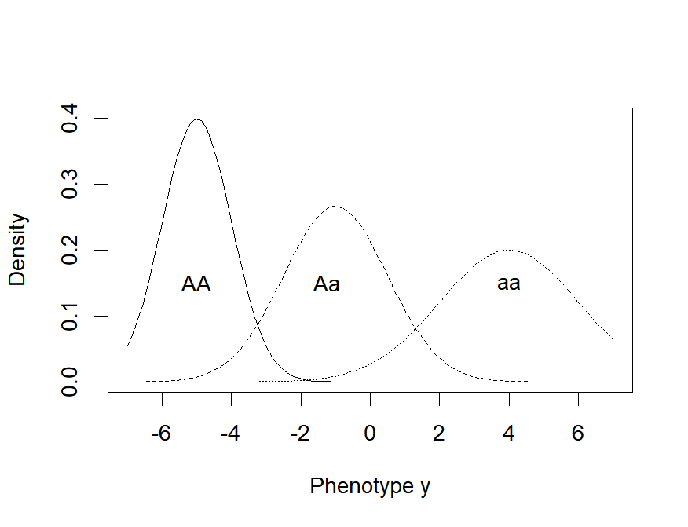

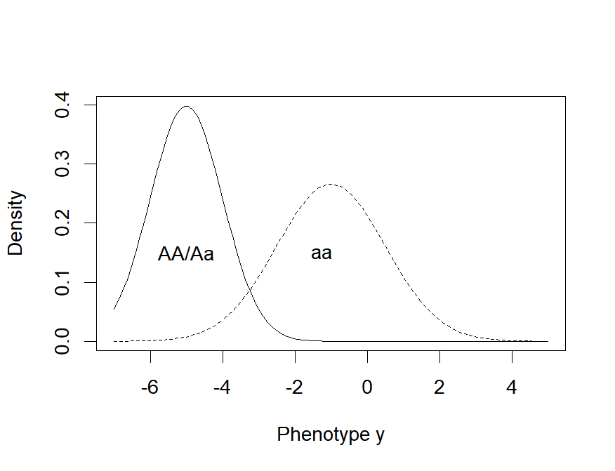

1. Codominant mixture.
2. Dominant mixture.

Figure 1: Examples of commingled distributions in genetics.

### 3.1 Generation of continuous distributions in *SimCorrMix*

Continuous variables, including components of mixture variables, are created using either Fleishman (1978)’s third-order (`method = "Fleishman"`) or Headrick (2002)’s fifth-order (`method =` `"Polynomial"`) PMT applied to standard normal variables. The transformation is expressed as follows:
$$\label{System1}
Y = p \left(Z \right) = c_{0} + c_{1}Z + c_{2}Z^2 + c_{3}Z^3 + c_{4}Z^4 + c_{5}Z^5,\ Z \sim N\left(0, 1 \right), \tag{3}$$
where $c_{4} = c_{5} = 0$ for Fleishman’s method. The real constants are calculated by *SimMultiCorrData*’s `find_constants`, which solves the system of non-linear equations given in `poly` or `fleish`. The simulation functions `corrvar` and `corrvar2` contain checks to see if any distributions are repeated for non-mixture or components of mixture variables. If so, these are noted so the constants are only calculated once, decreasing simulation time. Mixture variables are generated from their components based on random multinomial variables described by their mixing probabilities (using *stat*’s `rmultinom`).

The fifth-order PMT allows additional control over the fifth and sixth moments of the generated distribution. In addition, the range of feasible standardized kurtosis $\left(\gamma_{2}\right)$ values, given skew $\left(\gamma_{1}\right)$ and standardized fifth $\left(\gamma_{3}\right)$ and sixth $\left(\gamma_{4}\right)$ cumulants, is larger than with the third-order PMT. For example, Fleishman’s method can not be used to generate a non-normal distribution with a ratio of $\gamma_{1}^2/\gamma_{2} > 9/14$. This eliminates the ${{\chi}^{2}}$ family of distributions, which has a constant ratio of $\gamma_{1}^2/\gamma_{2} = 2/3$ (Headrick and Kowalchuk 2007). The fifth-order method also generates more distributions with valid PDFs. However, if the fifth and sixth cumulants do not exist, the Fleishman approximation should be used. This would be the case for $t$-distributions with degrees of freedom below $7$.

For some sets of cumulants, it is either not possible to find power method constants (indicated by a `stop` error) or the calculated constants do not generate valid PDF’s (indicated in the simulation function results). For the fifth-order PMT, adding a value to the sixth cumulant may provide solutions. This can be done for non-mixture variables in `Six` or components of mixture variables in `mix_Six`, and `find_constants` will use the smallest correction that yields a valid PDF. Another possible reason for function failure is that the standardized kurtosis for a distribution is below the lower boundary of values which can be generated using the third or fifth-order PMT. This boundary can be found with *SimMultiCorrData*’s `calc_lower_skurt` using skew (for `method = "Fleishman"`) and standardized fifth and sixth cumulants (for `method = "Polynomial"`).

### 3.2 Expected cumulants of continuous mixture variables

The PMT simulates continuous variables by matching standardized cumulants derived from central moments. Using standardized cumulants decreases the complexity involved in calculations when a distribution has large central moments. In view of this, let $Y$ be a real-valued random variable with cumulative distribution function $F$. Define the central moments, ${\mu}_{r}$, of $Y$ as:

$$\label{System2}
{\mu}_{r} = {\mu}_{r}\left(Y \right) = \mathbb{E}[y-\mu]^{r} = \int_{-\infty}^{+\infty}{\left[y-\mu \right]}^{r}dF\left(y \right). \tag{4}$$

The standardized cumulants are found by dividing the first six cumulants ${\kappa}_{1}$ - ${\kappa}_{6}$ by $\sqrt{{{\kappa}_{2}}^{r}} = \left({\sigma}^{2}\right)^{r/2} = {\sigma}^{r}$, where ${\sigma}^{2}$ is the variance of $Y$ and $r$ is the order of the cumulant (Kendall and Stuart 1977):

$$\begin{aligned}
0 &= \frac{{\kappa}_{1}}{\sqrt{{{\kappa}_{2}}^{1}}} = \frac{{\mu}_{1}}{{\sigma}^{1}} \label{scum1}
\end{aligned} \tag{5}$$

$$\begin{aligned}
1 &= \frac{{\kappa}_{2}}{\sqrt{{{\kappa}_{2}}^{2}}} = \frac{{\mu}_{2}}{{\sigma}^{2}} \label{scum2}
\end{aligned} \tag{6}$$

$$\begin{aligned}
{\gamma}_{1} &= \frac{{\kappa}_{3}}{\sqrt{{{\kappa}_{2}}^{3}}} = \frac{{\mu}_{3}}{{\sigma}^{3}} \label{scum3}
\end{aligned} \tag{7}$$

$$\begin{aligned}
{\gamma}_{2} &= \frac{{\kappa}_{4}}{\sqrt{{{\kappa}_{2}}^{4}}} = \frac{{\mu}_{4}}{{\sigma}^{4}} - 3 \label{scum4}
\end{aligned} \tag{8}$$

$$\begin{aligned}
{\gamma}_{3} &= \frac{{\kappa}_{5}}{\sqrt{{{\kappa}_{2}}^{5}}} = \frac{{\mu}_{5}}{{\sigma}^{5}} - 10{\gamma}_{1} \label{scum5}
\end{aligned} \tag{9}$$

$$\begin{aligned}
{\gamma}_{4} &= \frac{{\kappa}_{6}}{\sqrt{{{\kappa}_{2}}^{6}}} = \frac{{\mu}_{6}}{{\sigma}^{6}} - 15{\gamma}_{2} - 10{{\gamma}_{1}}^{2} - 15. \label{scum6}
\end{aligned} \tag{10}$$

The values $\gamma_1$, $\gamma_2$, $\gamma_3$, and $\gamma_4$ correspond to skew, standardized kurtosis (so that the normal distribution has a value of 0, subsequently referred to as skurtosis), and standardized fifth and sixth cumulants. The corresponding sample values for the above can be obtained by replacing ${\mu}_{r}$ by ${m}_{r} = \sum_{j=1}^{n}{\left({x}_{j}-{m}_{1}\right)}^{r}/n$ (Headrick 2002).

The standardized cumulants for a continuous mixture variable can be derived in terms of the standardized cumulants of its component distributions. Suppose the goal is to simulate a continuous mixture variable $Y$ with PDF $h_{Y}(y)$ that contains two component distributions $Y_a$ and $Y_b$ with mixing parameters $\pi_a$ and $\pi_b$:
$$h_{Y}\left(y\right) = \pi_a f_{Y_a}\left(y\right) + \pi_b g_{Y_b}\left(y\right),\ y\ \in\ \mathbf{Y},\ \pi_a\ \in\ \left(0,\ 1\right),\ \pi_b\ \in\ \left(0,\ 1\right),\ \pi_a + \pi_b = 1. \label{System3b}
\tag{11}$$
Here,
$$\label{System4b}
Y_a = \sigma_a Z_a' + \mu_a,\ Y_a \sim f_{Y_a}\left(y\right),\ y\ \in\ \mathbf{Y_a} \ \ \textrm{and} \ \ Y_b = \sigma_b Z_b' + \mu_b,\ Y_b \sim g_{Y_b}\left(y\right),\ y\ \in\ \mathbf{Y_b} \tag{12}$$
so that $Y_a$ and $Y_b$ have expected values $\mu_a$ and $\mu_b$ and variances $\sigma_a^2$ and $\sigma_b^2$. Assume the variables $Z_a'$ and $Z_b'$ are generated with zero mean and unit variance using Headrick’s fifth-order PMT given the specified values for skew $\left(\gamma_{1_a}',\ \gamma_{1_b}'\right)$, skurtosis $\left(\gamma_{2_a}',\ \gamma_{2_b}'\right)$, and standardized fifth $\left(\gamma_{3_a}',\ \gamma_{3_b}'\right)$ and sixth $\left(\gamma_{4_a}',\ \gamma_{4_b}'\right)$ cumulants:
$$\label{System5}
\begin{split}
Z_a' &= c_{0_a} + c_{1_a}Z_a + c_{2_a}Z_a^2 + c_{3_a}Z_a^3 + c_{4_a}Z_a^4 + c_{5_a}Z_a^5,\ Z_a \sim N\left(0,\ 1\right) \\
Z_b' &= c_{0_b} + c_{1_b}Z_b + c_{2_b}Z_b^2 + c_{3_b}Z_b^3 + c_{4_b}Z_b^4 + c_{5_b}Z_b^5,\ Z_b \sim N\left(0,\ 1\right).
\end{split} \tag{13}$$
The constants $c_{0_a},\ ...,\ c_{5_a}$ and $c_{0_b},\ ...,\ c_{5_b}$ are the solutions to the system of equations given in *SimMultiCorrData*’s `poly` function and calculated by `find_constants`. Similar results hold for Fleishman’s third-order PMT, where the constants $c_{0_a},\ ...,\ c_{3_a}$ and $c_{0_b},\ ...,\ c_{3_b}$ are the solutions to the system of equations given in `fleish` $\left(c_{4_a} = c_{5_a} = c_{4_b} = c_{5_b} = 0\right)$.

The $r^{th}$ expected value of $Y$ can be expressed as:
$$\label{System6b}
\begin{split}
\mathbb{E}\left[Y^r\right] &= \int y^r h_{Y}\left(y\right) dy = \pi_a \int y^r f_{Y_a}\left(y\right) dy + \pi_b \int y^r g_{Y_b}\left(y\right) dy \\
&= \pi_a \mathbb{E}\left[Y_a^r\right] + \pi_b \mathbb{E}\left[Y_b^r\right].
\end{split} \tag{14}$$
Equation (14) can be used to derive expressions for the mean, variance, skew, skurtosis, and standardized fifth and sixth cumulants of $Y$ in terms of the $r^{th}$ expected values of $Y_a$ and $Y_b$. See 11.1 in the Appendix for the expressions and proofs.

#### Extension to more than two component distributions

If the desired mixture distribution $Y$ contains more than two component distributions, the expected values of $Y$ are again expressed as sums of the expected values of the component distributions, with weights equal to the associated mixing parameters. For example, assume $Y$ contains $k$ component distributions $Y_{1},\ ...,\ Y_{k}$ with mixing parameters given by $\pi_{1},\ ...,\ \pi_{k}$, where $\sum_{i=1}^{k} \pi_{i} = 1$. The component distributions are described by the following parameters: means $\mu_{1},\ ...,\ \mu_{k}$, variances $\sigma_{1}^2,\ ...,\ \sigma_{k}^2$, skews $\gamma_{1_{1}}',\ ...,\ \gamma_{1_{k}}'$, skurtoses $\gamma_{2_{1}}',\ ...,\ \gamma_{2_{k}}'$, fifth cumulants $\gamma_{3_{1}}',\ ...,\ \gamma_{3_{k}}'$, and sixth cumulants $\gamma_{4_{1}}',\ ...,\ \gamma_{4_{k}}'$. Then the $r^{th}$ expected value of $Y$ can be expressed as:
$$\mathbb{E}\left[Y^r\right] = \int y^r h_{Y}\left(y\right) dy = \sum_{i=1}^{k} \pi_{i} \int y^r f_{Y_{i}}\left(y\right) dy = \sum_{i=1}^{k} \pi_{i} E_{f_{i}}\left[Y_{i}^r\right]. \label{System23b}
\tag{15}$$
Therefore, a method similar to that above can be used to derive the system of equations defining the mean, variance, skew, skurtosis, and standardized fifth and sixth cumulants of $Y$. These equations are used within the function `calc_mixmoments` to determine the values for a mixture variable. The `summary_var` function executes `calc_mixmoments` to provide target distributions for simulated continuous mixture variables.

#### Example with Normal and Beta mixture variables

Let $Y_1$ be a mixture of Normal(-5, 2), Normal(1, 3), and Normal(7, 4) distributions with mixing parameters $0.36, 0.48,$ and $0.16$. This variable could represent a continuous trait with a codominant mixture distribution, as in Figure 1a, where $p_A = 0.6$ and $p_a = 0.4$. Let $Y_2$ be a mixture of Beta(13, 11) and Beta(13, 4) distributions with mixing parameters $0.3$ and $0.7$. Beta-mixture models are widely used in bioinformatics to represent correlation coefficients. These could arise from pathway analysis of a relevant gene to study if gene-expression levels are correlated with those of other genes. The correlations could also describe the expression levels of the same gene measured in different studies, as in meta-analyses of multiple gene-expression experiments. Since expression varies greatly across genes, the correlations may come from different probability distributions within one mixture distribution. Each component distribution represents groups of genes with similar behavior. Ji et al. (2005) proposed a Beta-mixture model for correlation coefficients. Laurila et al. (2011) extended this model to methylation microarray data in order to reduce dimensionality and detect fluctuations in methylation status between various samples and tissues. Other extensions include cluster analysis (Dai et al. 2009), single nucleotide polymorphism (SNP) analysis (Fu et al. 2011), pattern recognition and image processing (Bouguila et al. 2006; Ma and Leijon 2011), and quantile normalization to correct probe design bias (Teschendorff et al. 2013). Since these methods assume independence among components, Dai and Charnigo (2015) developed a compound hierarchical correlated Beta-mixture model to permit correlations among components, applying it to cluster mouse transcription factor DNA binding data.

The standardized cumulants for the Normal and Beta mixtures using the fifth-order PMT are found as follows:

```r
  library("SimCorrMix")
  B1 <- calc_theory("Beta", c(13, 11))
  B2 <- calc_theory("Beta", c(13, 4))
  mix_pis <- list(c(0.36, 0.48, 0.16), c(0.3, 0.7))
  mix_mus <- list(c(-5, 1, 7), c(B1[1], B2[1]))
  mix_sigmas <- list(c(sqrt(2), sqrt(3), sqrt(4)), c(B1[2], B2[2]))
  mix_skews <- list(c(0, 0, 0), c(B1[3], B2[3]))
  mix_skurts <- list(c(0, 0, 0), c(B1[4], B2[4]))
  mix_fifths <- list(c(0, 0, 0), c(B1[5], B2[5]))
  mix_sixths <- list(c(0, 0, 0), c(B1[6], B2[6]))
  Nstcum <- calc_mixmoments(mix_pis[[1]], mix_mus[[1]], mix_sigmas[[1]],
    mix_skews[[1]], mix_skurts[[1]], mix_fifths[[1]], mix_sixths[[1]])
  Nstcum
  ##       mean         sd       skew   kurtosis      fifth      sixth
  ## -0.2000000  4.4810713  0.3264729 -0.6238472 -1.0244454  1.4939902
  Bstcum <- calc_mixmoments(mix_pis[[2]], mix_mus[[2]], mix_sigmas[[2]],
    mix_skews[[2]], mix_skurts[[2]], mix_fifths[[2]], mix_sixths[[2]])
  Bstcum
  ##      mean         sd       skew   kurtosis      fifth      sixth
  ## 0.6977941  0.1429099 -0.4563146 -0.5409080  1.7219898  0.5584577
```

*SimMultiCorrData*’s `calc_theory` was used first to obtain the standardized cumulants for each of the Beta distributions.

### 3.3 Calculation of intermediate correlations for continuous variables

The target correlation matrix `rho` in the simulation functions `corrvar` and `corrvar2` is specified in terms of the correlations with components of continuous mixture variables. This allows the user to set the correlation between components of the same mixture variable to any desired value. If this correlation is small (i.e., $0$–$0.2$), the intermediate correlation matrix `Sigma` may need to be converted to the nearest positive-definite (PD) matrix. This is done within the simulation functions by specifying `use.nearPD = TRUE`, and Higham (2002)’s algorithm is executed with the [*Matrix*](https://CRAN.R-project.org/package=Matrix) package’s `nearPD` function (Bates and Maechler 2017). Otherwise, negative eigenvalues are replaced with $0$.

The function `intercorr_cont` calculates the intermediate correlations for the standard normal variables used in Equation (3). This is necessary because the transformation decreases the absolute value of the final correlations. The function uses Equation 7b derived by Headrick and Sawilowsky (1999 28) for the third-order PMT and Equation 26 derived by Headrick (2002 694) for the fifth-order PMT.

### 3.4 Approximate correlations for continuous mixture variables:

Even though the correlations for the continuous mixture variables are set at the component level, we can approximate the resulting correlations for the mixture variables. Assume $Y_1$ and $Y_2$ are two continuous mixture variables. Let $Y_1$ have $k_1$ components with mixing probabilities $\alpha_1, ..., \alpha_{k_1}$ and standard deviations $\sigma_{1_1}, ..., \sigma_{1_{k_1}}$. Let $Y_2$ have $k_2$ components with mixing probabilities $\beta_1, ..., \beta_{k_2}$ and standard deviations $\sigma_{2_1}, ..., \sigma_{2_{k_2}}$.

#### Correlation between continuous mixture variables $Y_1$ and $Y_2$

The correlation between the mixture variables $Y_1$ and $Y_2$ is given by:
$$\rho_{Y_1 Y_2} = \frac{\mathbb{E}\left[Y_1 Y_2\right] - \mathbb{E}\left[Y_1\right]\mathbb{E}\left[Y_2\right]}{\sigma_1 \sigma_2}, \label{System24a}
\tag{16}$$
where $\sigma_1^2$ is the variance of $Y_1$ and $\sigma_2^2$ is the variance of $Y_2$. Equation (16) requires the expected value of the product of $Y_1$ and $Y_2$. Since $Y_1$ and $Y_2$ may contain any number of components and these components may have any continuous distribution, there is no general way to determine this expected value. Therefore, it is approximated by expressing $Y_1$ and $Y_2$ as sums of their component variables:
$$\rho_{Y_1 Y_2} = \frac{\mathbb{E}\left[\left(\sum_{i = 1}^{k_1} \alpha_i Y_{1_i}\right) \left(\sum_{j = 1}^{k_2} \beta_j Y_{2_j}\right)\right] - \mathbb{E}\left[\sum_{i = 1}^{k_1} \alpha_i Y_{1_i}\right]\mathbb{E}\left[\sum_{j = 1}^{k_2} \beta_j Y_{2_j}\right]}{\sigma_1 \sigma_2}, \label{System24b}
\tag{17}$$
where
$$\label{System25}
\begin{split}
\mathbb{E}\left[\left(\sum_{i = 1}^{k_1} \alpha_i Y_{1_i}\right) \left(\sum_{j = 1}^{k_2} \beta_j Y_{2_j}\right)\right] &= \mathbb{E}\left[\alpha_1 Y_{1_1} \beta_1 Y_{2_1} + \alpha_1 Y_{1_1} \beta_2 Y_{2_2} + ... + \alpha_{k_1} Y_{1_{k_1}} \beta_{k_2} Y_{2_{k_2}}\right] \\
&= \alpha_1 \beta_1 \mathbb{E}\left[Y_{1_1} Y_{2_1}\right] + \alpha_1 \beta_2 \mathbb{E}\left[Y_{1_1} Y_{2_2}\right] + ... + \alpha_{k_1} \beta_{k_2} \mathbb{E}\left[Y_{1_{k_1}} Y_{2_{k_2}}\right].
\end{split} \tag{18}$$
Using the general correlation equation, for $1 \leq i \leq k_1$ and $1 \leq j \leq k_2$:
$$\mathbb{E}\left[Y_{1_i} Y_{2_j}\right] = \sigma_{1_i} \sigma_{2_j} \rho_{Y_{1_i} Y_{2_j}} + \mathbb{E}\left[Y_{1_i}\right] \mathbb{E}\left[Y_{2_j}\right], \label{System25b}
\tag{19}$$
so that we can rewrite $\rho_{Y_1 Y_2}$ as:
$$\label{System26}
\begin{split}
\rho_{Y_1 Y_2} &= \frac{\alpha_1 \beta_1 \left(\sigma_{1_1} \sigma_{2_1} \rho_{Y_{1_1} Y_{2_1}} + \mathbb{E}\left[Y_{1_1}\right] \mathbb{E}\left[Y_{2_1}\right]\right)}{\sigma_1 \sigma_2} \\
&\qquad \ \ \qquad \ \ + ... + \frac{\alpha_{k_1} \beta_{k_2} \left(\sigma_{1_{k_1}} \sigma_{2_{k_2}} \rho_{Y_{1_{k_1}} Y_{2_{k_2}}} + \mathbb{E}\left[Y_{1_{k_1}}\right] \mathbb{E}\left[Y_{2_{k_2}}\right]\right)}{\sigma_1 \sigma_2} \\
&\qquad \ \ - \frac{\alpha_1 \beta_1 \mathbb{E}\left[Y_{1_1}\right] \mathbb{E}\left[Y_{2_1}\right] + ... + \alpha_{k_1} \beta_{k_2} \mathbb{E}\left[Y_{1_{k_1}}\right] \mathbb{E}\left[Y_{2_{k_2}}\right]}{\sigma_1 \sigma_2} \\
&= \frac{\sum_{i = 1}^{k_1} \alpha_i \sigma_{1_i} \sum_{j = 1}^{k_2} \beta_j \sigma_{2_j} \rho_{Y_{1_i}, Y_{2_j}}}{\sigma_1 \sigma_2}.
\end{split} \tag{20}$$
Extending the example from 3.2.1, assume there are now three variables: $Y_1$ (the Normal mixture), $Y_2$ (the Beta mixture), and $Y_3$ (a zero-inflated Poisson variable with mean 5 and probability of a structural zero set at 0.1). Let the target correlations among the components of $Y_1$, the components of $Y_2$, and $Y_3$ be $0.4$. The components of $Y_1$ have a weak correlation of $0.1$ and the components of $Y_2$ are independent. The resulting correlation between $Y_1$ and $Y_2$ is approximated as:

```r
  rho <- matrix(0.4, 6, 6)
  rho[1:3, 1:3] <- matrix(0.1, 3, 3)
  rho[4:5, 4:5] <- matrix(0, 2, 2)
  diag(rho) <- 1
  rho_M1M2(mix_pis, mix_mus, mix_sigmas, rho[1:3, 4:5])
  ## [1] 0.103596
```

Note that `rho` has 6 columns because $k_1 = 3$, $k_2 = 2$, and $k_1 + k_2 + 1 = 6$.

#### Correlation between continuous mixture variable $Y_1$ and other random variable $Y_3$

Here $Y_3$ can be an ordinal, a continuous non-mixture, or a regular or zero-inflated Poisson or Negative Binomial variable. The correlation between the mixture variable $Y_1$ and $Y_3$ is given by:
$$\rho_{Y_1 Y_3} = \frac{\mathbb{E}\left[Y_1 Y_3\right] - \mathbb{E}\left[Y_1\right]\mathbb{E}\left[Y_3\right]}{\sigma_1 \sigma_3}, \label{System28a}
\tag{21}$$
where $\sigma_3^2$ is the variance of $Y_3$. Equation (21) requires the expected value of the product of $Y_1$ and $Y_3$, which is again approximated by expressing $Y_1$ as a sum of its component variables:
$$\rho_{Y_1 Y_3} = \frac{\mathbb{E}\left[\left(\sum_{i = 1}^{k_1} \alpha_i Y_{1_i}\right) Y_3\right] - \mathbb{E}\left[\sum_{i = 1}^{k_1} \alpha_i Y_{1_i}\right]\mathbb{E}\left[Y_3\right]}{\sigma_1 \sigma_3}, \label{System28b}
\tag{22}$$
where
$$\label{System29}
\begin{split}
\mathbb{E}\left[\left(\sum_{i = 1}^{k_1} \alpha_i Y_{1_i}\right) Y_3\right] &= \mathbb{E}\left[\alpha_1 Y_{1_1} Y_3 + \alpha_2 Y_{1_2} Y_3 + ... + \alpha_{k_1} Y_{1_{k_1}} Y_3\right] \\
&= \alpha_1 \mathbb{E}\left[Y_{1_1} Y_3\right] + \alpha_2 \mathbb{E}\left[Y_{1_2} Y_3\right] + ... + \alpha_{k_1} \mathbb{E}\left[Y_{1_{k_1}} Y_3\right].
\end{split} \tag{23}$$
Using the general correlation equation, for $1 \leq i \leq k_1$:
$$\mathbb{E}\left[Y_{1_i} Y_3\right] = \sigma_{1_i} \sigma_3 \rho_{Y_{1_i} Y_3} + \mathbb{E}\left[Y_{1_i}\right] \mathbb{E}\left[Y_3\right], \label{System29b}
\tag{24}$$
so that we can rewrite $\rho_{Y_1 Y_3}$ as:
$$\label{System30}
\begin{split}
\rho_{Y_1 Y_3} &= \frac{\alpha_1 \left(\sigma_{1_1} \sigma_3 \rho_{Y_{1_1} Y_3} + \mathbb{E}\left[Y_{1_1}\right] \mathbb{E}\left[Y_3\right]\right) + ... + \alpha_{k_1} \left(\sigma_{1_{k_1}} \sigma_3 \rho_{Y_{1_{k_1}} Y_3} + \mathbb{E}\left[Y_{1_{k_1}}\right] \mathbb{E}\left[Y_3\right]\right)}{\sigma_1 \sigma_3} \\
&\qquad \ \ - \frac{\alpha_1 \mathbb{E}\left[Y_{1_1}\right] \mathbb{E}\left[Y_3\right] + ... + \alpha_{k_1} \mathbb{E}\left[Y_{1_{k_1}}\right] \mathbb{E}\left[Y_3\right]}{\sigma_1 \sigma_3} \\
&= \frac{\sum_{i = 1}^{k_1} \alpha_i \sigma_{Y_{1_i}} \rho_{Y_{1_i} Y_3}}{\sigma_1}.
\end{split} \tag{25}$$
Continuing with the example, the correlations between $Y_1$ and $Y_3$ and between $Y_2$ and $Y_3$ are approximated as:

```r
  rho_M1Y(mix_pis[[1]], mix_mus[[1]], mix_sigmas[[1]], rho[1:3, 6])
  ## [1] 0.1482236
  rho_M1Y(mix_pis[[2]], mix_mus[[2]], mix_sigmas[[2]], rho[4:5, 6])
  ## [1] 0.2795669
```

The accuracy of these approximations can be determined through simulation:

```r
  means <- c(Nstcum[1], Bstcum[1])
  vars <- c(Nstcum[2]^2, Bstcum[2]^2)
  seed <- 184
  Sim1 <- corrvar(n = 100000, k_mix = 2, k_pois = 1, method = "Polynomial",
    means = means, vars = vars, mix_pis = mix_pis, mix_mus = mix_mus,
    mix_sigmas = mix_sigmas, mix_skews = mix_skews, mix_skurts = mix_skurts,
    mix_fifths = mix_fifths, mix_sixths = mix_sixths, lam = 5, p_zip = 0.1,
    rho = rho, seed = seed, use.nearPD = FALSE)
  ## Total Simulation time: 0.065 minutes
  names(Sim1)
  ## [1] "constants"        "Y_cont"           "Y_comp"           "sixth_correction"
  ## [5] "valid.pdf"        "Y_mix"            "Y_pois"           "Sigma"
  ## [9] "Error_Time"       "Time"             "niter"
  Sum1 <- summary_var(Y_comp = Sim1$Y_comp, Y_mix = Sim1$Y_mix,
    Y_pois = Sim1$Y_pois, means = means, vars = vars, mix_pis = mix_pis,
    mix_mus = mix_mus, mix_sigmas = mix_sigmas, mix_skews = mix_skews,
    mix_skurts = mix_skurts, mix_fifths = mix_fifths, mix_sixths = mix_sixths,
    lam = 5, p_zip = 0.1, rho = rho)
  names(Sum1)
  ## [1] "cont_sum"   "target_sum" "mix_sum"    "target_mix" "rho_mix"    "pois_sum"
  ## [7] "rho_calc"   "maxerr"
  Sum1$rho_mix
  ##           [,1]      [,2]      [,3]
  ## [1,] 1.0000000 0.1012219 0.1475749
  ## [2,] 0.1012219 1.0000000 0.2776299
  ## [3,] 0.1475749 0.2776299 1.0000000
```

The results show that Equation (20) and Equation (25) provided good approximations to the simulated correlations. 8 also compares approximated expected correlations for continuous mixture variables with simulated correlations.

Figure 2 displays the PDF of the Normal mixture variable and the simulated values of the zero-inflated Poisson (ZIP) variable obtained using *SimCorrMix*’s graphing functions. These functions are written with [*ggplot2*](https://CRAN.R-project.org/package=ggplot2) functions and the results are `ggplot` objects that can be saved or further modified (Wickham and Chang 2016). As demonstrated below, the target distribution, specified by distribution name and parameters (39 distributions currently available by name) or PDF function `fx`, can be overlayed on the plot for continuous or count variables.

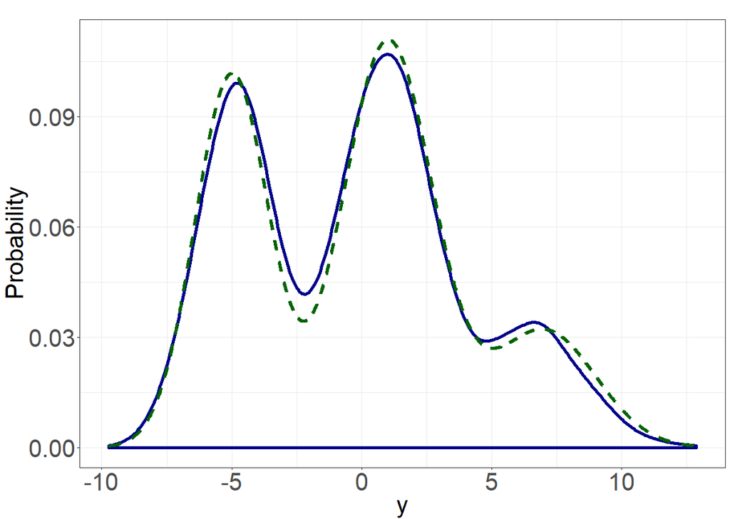

[figure not shown]

```r
  plot_simpdf_theory(sim_y = Sim1$Y_mix[, 1], title = "", sim_size = 2,
    target_size = 2, fx = function(x) mix_pis[[1]][1] *
      dnorm(x, mix_mus[[1]][1], mix_sigmas[[1]][1]) + mix_pis[[1]][2] *
      dnorm(x, mix_mus[[1]][2], mix_sigmas[[1]][2]) + mix_pis[[1]][3] *
      dnorm(x, mix_mus[[1]][3], mix_sigmas[[1]][3]), lower = -10, upper = 10,
    legend.position = "none", axis.text.size = 30, axis.title.size = 30)
  plot_simtheory(sim_y = Sim1$Y_pois[, 1], title = "", cont_var = FALSE,
    binwidth = 0.5, Dist = "Poisson", params = c(5, 0.1),
    legend.position = "none", axis.text.size = 30, axis.title.size = 30)
```

1. PDF of Normal mixture variable.
2. Simulated values of ZIP variable.

Figure 2: Graphs of variables (simulated = blue, target = green).

The **Continuous Mixture Distributions** vignette explains how to compare simulated to theoretical distributions of continuous mixture variables, as demonstrated here for the Beta mixture variable $Y_2$ (adapted from Headrick and Kowalchuk 2007):

1. Obtain the standardized cumulants for the target mixture variable $Y_2^*$ and its components: these were found above using `calc_mixmoments` and `calc_theory`.
2. Obtain the PMT constants for the components of $Y_2^*$: these are returned in the simulation result `Sim1$constants`.
3. Determine whether these constants produce valid PDF’s for the components of $Y_2$ (and therefore for $Y_2$): this is indicated for all continuous variables in the simulation result `Sim1$valid.pdf`.

   ```r
     ## [1] "TRUE" "TRUE" "TRUE" "TRUE" "TRUE"
   ```

4. Select a critical value from the distribution of $Y_2^*$, i.e. $y_2^*$ such that $\Pr\left[Y_2^* \ge y_2^*\right] = \alpha$, for the desired significance level $\alpha$: Let $\alpha = 0.05$. Since there are no quantile functions for mixture distributions, determine where the cumulative probability equals $1 - \alpha = 0.95$.

   ```r
     beta_fx <- function(x) mix_pis[[2]][1] * dbeta(x, 13, 11) +
       mix_pis[[2]][2] * dbeta(x, 13, 4)
     beta_cfx <- function(x, alpha, fx = beta_fx) {
       integrate(function(x, FUN = fx) FUN(x), -Inf, x, subdivisions = 1000,
         stop.on.error = FALSE)$value - (1 - alpha)
     }
     y2_star <- uniroot(beta_cfx, c(0, 1), tol = 0.001, alpha = 0.05)$root
     y2_star
     ## [1] 0.8985136
   ```

5. Calculate the cumulative probability for the simulated mixture variable $Y_2$ up to $y_2^*$ and compare to $1 - \alpha$: The function `sim_cdf_prob` from *SimMultiCorrData* calculates cumulative probabilities.

   ```r
     sim_cdf_prob(sim_y = Sim1$Y_mix[, 2], delta = y2_star)$cumulative_prob
     ## [1] 0.9534
   ```

   This is approximately equal to the $1 - \alpha$ value of $0.95$, indicating that the simulation provides a good approximation to the theoretical distribution.
6. Plot a graph of $Y_2^*$ and $Y_2$: Figure 3 shows the PDF and empirical CDF obtained as follows (`plot_sim_cdf` is in *SimMultiCorrData*):

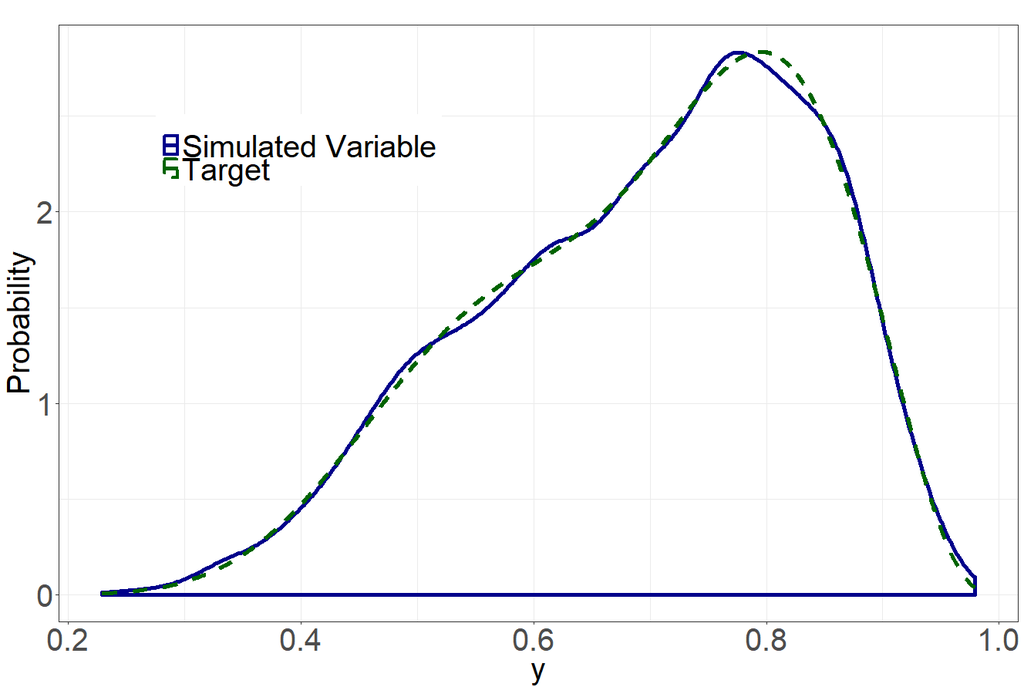

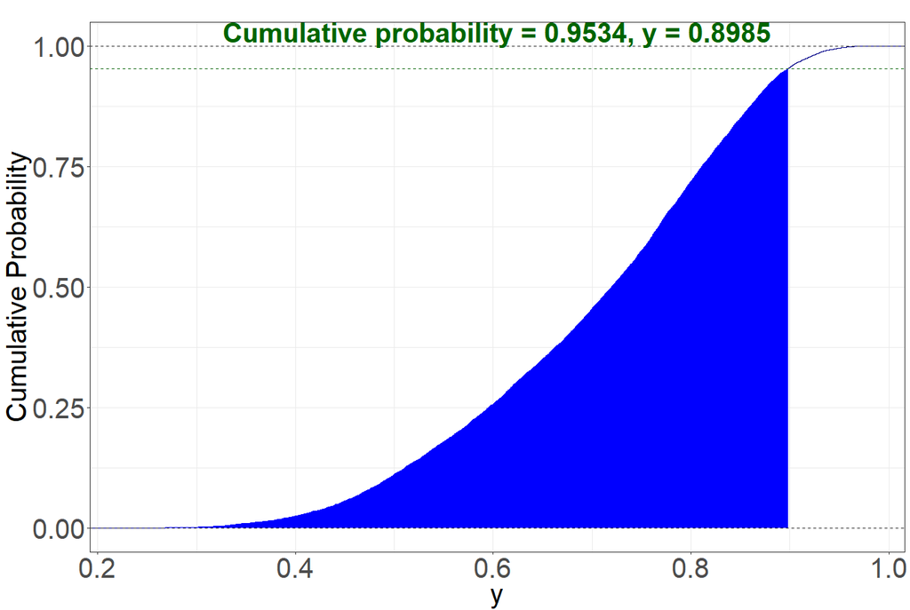

   ```r
     plot_simpdf_theory(sim_y = Sim1$Y_mix[, 2], title = "", sim_size = 2,
       target_size = 2, fx = beta_fx, lower = 0, upper = 1,
       legend.position = c(0.4, 0.85), legend.text.size = 30,
       axis.text.size = 30, axis.title.size = 30)
     plot_sim_cdf(sim_y = Sim1$Y_mix[, 2], title = "", calc_cprob = TRUE,
       delta = y2_star, text.size = 30, axis.text.size = 30, axis.title.size = 30)
   ```

1. PDF.
2. CDF.

Figure 3: Graphs of the Beta mixture variable.

## 4 Count mixture distributions

*SimCorrMix* extends the methods in *SimMultiCorrData* for regular Poisson and Negative Binomial (NB) variables to zero-inflated Poisson and NB variables. All count variables are generated using the inverse CDF method with distribution functions imported from *VGAM*. The CDF of a standard normal variable has a uniform distribution. The appropriate quantile function $F_{Y}^{-1}$ is applied to this uniform variable with the designated parameters to generate the count variable: $Y = F_{y}^{-1}\left(\Phi\left(Z\right)\right)$. The order within all parameters for count variables should be $1^{st}$ regular and $2^{nd}$ zero-inflated.

A zero-inflated random variable $Y_{ZI}$ is a mixture of a degenerate distribution having the point mass at $0$ and another distribution $Y$ that contributes both zero and non-zero values. If the mixing probability is $\phi$, then:
$$\label{System31}
\Pr\left[Y_{ZI} = 0\right] = \phi + \left(1 - \phi\right)\Pr\left[Y = 0\right],\ \ 0 < \phi < 1. \tag{26}$$
Therefore, $\phi$ is the probability of a structural zero, and setting $\phi = 0$ reduces $Y_{ZI}$ to the variable $Y$. In *SimCorrMix*, $Y$ can have either a Poisson $\left(Y_P\right)$ or a Negative Binomial $\left(Y_{NB}\right)$ distribution.

### 4.1 Zero-inflated Poisson (ZIP) distribution

The model for $Y_{ZIP} \sim ZIP\left(\lambda,\ \phi\right),\ \lambda>0,\ 0 < \phi < 1$ is:
$$\label{System32}
\begin{split}
\Pr\left[Y_{ZIP} = 0\right] &= \phi + \left(1 - \phi\right) \exp\left(-\lambda\right) \\
\Pr\left[Y_{ZIP} = y\right] &= \left(1 - \phi\right) \exp\left(-\lambda\right) \frac{\lambda^y}{y!},\ \ y = 1, 2, ...
\end{split} \tag{27}$$
The mean of $Y_{ZIP}$ is $\left(1 - \phi\right) \lambda$, and the variance is $\lambda + \lambda^2 \phi/\left(1 - \phi\right)$ (Lambert 1992). The parameters $\lambda$ (mean of the regular Poisson component) and $\phi$ are specified in *SimCorrMix* through the inputs `lam` and `p_zip`. Setting `p_zip = 0` (the default setting) generates a regular Poisson variable.

The zero-deflated Poisson distribution is obtained by setting $\phi \in \left(-1/\left(\exp\left(\lambda\right) - 1\right),\ 0 \right)$, so that the probability of a zero count is less than the nominal Poisson value. In this case, $\phi$ no longer represents a probability. When $\phi = -1/\left(\exp\left(\lambda\right) - 1\right)$, the random variable has a positive-Poisson distribution. The probability of a zero response is $0$, and the other probabilities are scaled to sum to $1$.

### 4.2 Zero-inflated Negative Binomial (ZINB) distribution

A major limitation of the Poisson distribution is that the mean and variance are equal. In practice, population heterogeneity creates extra variability (overdispersion), e.g., if $Y$ represents the number of events which occur in a given time interval and the length of the observation period varies across subjects. If the length of these periods are available for each subject, an offset term may be used. Otherwise, the length can be considered a latent variable and the mean of the Poisson distribution for each subject is a random variable. If these means are described by a Gamma distribution, then $Y$ has a NB distribution, which has an extra parameter to account for overdispersion. However, an excessive number of zeros requires using a zero-inflated distribution. These extra (structural) zeros may arise from a subpopulation of subjects who are not at risk for the event during the study period. These subjects are still important to the analysis because they may possess different characteristics from the at-risk subjects (He et al. 2014).

The model for $Y_{ZINB} \sim ZINB\left(\eta,\ p,\ \phi\right),\ \eta>0,\ 0<p\leq1,\ \ 0 < \phi < 1$ is:
$$\label{System33}
\begin{split}
\Pr\left[Y_{ZINB} = 0\right] &= \phi + \left(1 - \phi\right) p^{\eta} \\
\Pr\left[Y_{ZINB} = y\right] &= \left(1 - \phi\right) \frac{\Gamma\left(y + \eta\right)}{\Gamma\left(\eta\right) y!} p^{\eta} \left(1 - p\right)^{\eta},\ \ y = 1, 2, ...
\end{split} \tag{28}$$
In this formulation, the Negative Binomial component $Y_{NB}$ represents the number of failures that occur in a sequence of independent Bernoulli trials before a target number of successes $\left(\eta\right)$ is reached. The probability of success in each trial is $p$. $Y_{NB}$ may also be parameterized by the mean $\mu$ (of the regular NB component) and dispersion parameter $\eta$ so that $p = \eta/\left(\eta + \mu\right)$ or $\mu = \eta \left(1-p\right)/p$. The mean of $Y_{ZINB}$ is $\left(1 - \phi\right) \mu$, and the variance is $\left(1 - \phi\right) \mu \left(1 + \mu \left(\phi + 1/\eta\right)\right)$ (Ismail and Zamani 2013; Zhang et al. 2016). The parameters $\eta$, $p$, $\mu$, and $\phi$ are specified through the inputs `size`, `prob`, `mu`, and `p_zinb`. Either `prob` or `mu` should be given for all NB and ZINB variables. Setting `p_zinb = 0` (the default setting) generates a regular NB variable.

The zero-deflated NB distribution may be obtained by setting $\phi \in \left(-p^{\eta}/\left(1 - p^{\eta}\right),\ 0 \right)$, so that the probability of a zero count is less than the nominal NB value. In this case, $\phi$ no longer represents a probability. The positive-NB distribution results when $\phi = -p^{\eta}/\left(1 - p^{\eta}\right)$. The probability of a zero response is $0$, and the other probabilities are scaled to sum to $1$.

### 4.3 Calculation of intermediate correlations for count variables

Fialkowski and Tiwari (2017) showed that this method is less accurate for positive correlations with small count variable means (i.e., less than $1$) or high negative correlations with large count variable means.

In correlation method 2, count variables are treated as "ordinal" variables, based on the methods of Barbiero and Ferrari (Ferrari and Barbiero 2012; Barbiero and Ferrari 2015b). The Poisson or NB support is made finite by removing a small user-specified value (specified by `pois_eps` and `nb_eps`) from the total cumulative probability. This truncation factor may differ for each count variable, but the default value is $0.0001$ (suggested by Barbiero and Ferrari 2015b). For example, `pois_eps = 0.0001` means that the support values removed have a total probability of $0.0001$ of occurring in the distribution of that variable. The effect is to remove improbable values, which may be of concern if the user wishes to replicate a distribution with outliers. The function `maxcount_support` creates these new supports and associated marginal distributions.

1. Count variable or ordinal-count variable pairs: The intermediate correlations are calculated using the correction loop of `ord_norm` (see 5).
2. Continuous-count variable pairs: Extending Demirtas et al. (2012)’s method, the intermediate correlations are the ratio of the target correlations to correction factors. The correction factor is the product of the power method correlation between the continuous variable and the normal variable used to generate it and the point-polyserial correlation between the ordinalized count variable and the normal variable used to generate it (Olsson et al. 1982). The functions `intercorr_cont_pois2` and `intercorr_cont_nb2` calculate these correlations.

This method performs best under the same circumstances as ordinal variables, i.e., when there are few categories and the probability of any given category is not very small. This occurs when the count variable has a small mean. Therefore, method 2 performs well in situations when method 1 has poor accuracy. In contrast, large means for the count variables would result in longer computational times. 8 compares the accuracy of correlation methods 1 and 2 under different scenarios.

## 5 Simulation of ordinal variables

Ordinal variables ($r \ge 2$ categories) are generated by discretizing standard normal variables at the quantiles determined from the cumulative probabilities specified in `marginal`. Each element of this list is a vector of length $r - 1$ (the $r^{th}$ value is $1$). If the support is not provided, the default is to use $\left\{1,\ 2,\ ...,\ r \right \}$ (Ferrari and Barbiero 2012). The tetrachoric correlation is used for the intermediate correlation of binary pairs (Emrich and Piedmonte 1991; Demirtas et al. 2012). The assumptions are that the binary variables arise from latent normal variables and the actual trait is continuous and not discrete. For $Y_1$ and $Y_2$, with success probabilities $p_1$ and $p_2$, the intermediate correlation $\rho_{Z_1 Z_2}$ is the solution to the following equation:
$$\label{System34b} \Phi\left[z\left(p_{1}\right),\ z\left(p_{2}\right),\ \rho_{Z_1 Z_2}\right] = \rho_{Y1Y2}\sqrt{p_{1}\left(1 - p_{1}\right)p_{2}\left(1 - p_{2}\right)} + p_{1}p_{2},
\tag{30}$$
where $z\left(p\right)$ indicates the $p^{th}$ quantile of the standard normal distribution.

If at least one ordinal variable has more than $2$ categories, `ord_norm` is called. Based on *SimMultiCorrData*’s `ordnorm` and *GenOrd*’s `ordcont` and `contord`, the algorithm to simulate `k_cat` ordinal random variables with target correlation matrix `rho0` is as follows:

1. Create the default `support` if necessary.
2. Use `norm_ord` to calculate the initial correlation of the ordinal variables (`rhoordold`) generated by discretizing `k_cat` random normal variates with correlation matrix set equal to `rho0`, using `marginal` and the corresponding normal quantiles. These correlations are calculated using means and variances found from multivariate normal probabilities determined by [*mvtnorm*](https://CRAN.R-project.org/package=mvtnorm)’s `pmvnorm` (Genz and Bretz 2009; Genz et al. 2017).
3. Let `rho` be the intermediate normal correlation updated in each iteration, `rhoord` be the ordinal correlation calculated in each iteration, `rhoold` be the intermediate correlation from the previous iteration (initialized at `rhoordold`), `it` be the iteration number, and `maxit` and `epsilon` be the user-specified maximum number of iterations and pairwise correlation error. For each variable pair, execute the following:
   1. If `rho0 = 0`, set `rho = 0`.
   2. While the absolute error between `rhoord` and `rho0` is greater than `epsilon` and `it` is less than `maxit`:
      1. If `rho0 * (rho0/rhoord) <= -1`:  
         `rho = rhoold * (1 + 0.1 * (1 - rhoold) * -sign(rho0 - rhoord))`.
      2. If `rho0 * (rho0/rhoord) >= 1`:  
         `rho = rhoold * (1 + 0.1 * (1 - rhoold) * sign(rho0 - rhoord))`.
      3. Else, `rho = rhoold * (rho0/rhoord)`.
      4. If `rho > 1`, set `rho = 1`. If `rho < -1`, set `rho = -1`.
      5. Calculate `rhoord` using `norm_ord` and the $2 \times 2$ correlation matrix formed by `rho`.
      6. Set `rhoold = rho` and increase `it` by $1$.
   3. Store the number of iterations in the matrix `niter`.
4. Return the final intermediate correlation matrix `SigmaC = rho` for the random normal variables. Discretize these to produce ordinal variables with the desired correlation matrix.

## 6 Calculation of correlation boundaries

For binary variable pairs, the correlation bounds are calculated as by Demirtas et al. (2012). The joint distribution is determined using the moments of a multivariate normal distribution (Emrich and Piedmonte 1991). For $Y_1$ and $Y_2$, with success probabilities $p_1$ and $p_2$, the boundaries are approximated by:
$$\label{System35}
\left\{\max \left(-\sqrt{\frac{p_1p_2}{q_1q_2}},\ -\sqrt{\frac{q_1q_2}{p_1p_2}} \right),\ \min \left(\sqrt{\frac{p_1q_2}{q_1p_2}},\ \sqrt{\frac{q_1p_2}{p_1q_2}} \right) \right\}, \tag{31}$$
where $q_1 = 1 - p_1$ and $q_2 = 1 - p_2$. If one of an ordinal variable pair has more than $2$ categories, randomly generated variables with the given `marginal` distributions and `support` values are used in Demirtas and Hedeker (2011)’s generate, sort, and correlate (GSC) algorithm. A large number (default $100,000$) of independent random samples from the desired distributions are generated. The lower bound is the sample correlation of the two variables sorted in opposite directions (i.e., one increasing and one decreasing). The upper bound is the sample correlation of the two variables sorted in the same direction.

The GSC algorithm is also used for continuous, continuous-ordinal, ordinal-count, and continuous-count variable pairs. Since count variables are treated as "ordinal" in correlation method 2, the correlation bounds for count variable pairs is found with the GSC algorithm after creating finite supports with associated marginal distributions (with `maxcount_support`). The correlation bounds for count variable pairs in correlation method 1 are the Fréchet-Hoeffding bounds (Fréchet 1957; Hoeffding 1994). For two random variables $Y_1$ and $Y_2$ with CDF’s $F_1$ and $F_2$, the correlation bounds are approximated by:
$$\label{System36}
\left\{\textrm{Cor} \left(F_1^{-1}\left(U\right), F_2^{-1}\left(1 - U\right) \right),\ \textrm{Cor} \left(F_1^{-1}\left(U\right), F_2^{-1}\left(U\right) \right) \right\}, \tag{32}$$
where $U$ is a Uniform(0, 1) random variable of default length $100,000$.

### 6.1 Example with multiple variable types

Consider the Normal and Beta mixture variables from 3. Additional variables are an ordinal variable with three equally-weighted categories (e.g., drug treatment), two zero-inflated Poisson variables with means $0.5$ and $1$ (for the regular Poisson components) and structural zero probabilities $0.1$ and $0.2$, and two zero-inflated NB variables with means $0.5$ and $1$ (for the regular NB components), success probabilities $0.8$ and $0.6$, and structural zero probabilities $0.1$ and $0.2$. The target pairwise correlation is set at $-0.5$. The components of the Normal mixture variable again have weak correlation of $0.1$ and those for the Beta mixture variable are uncorrelated. The parameter inputs are first checked with `validpar`.

```r
  marginal <- list(c(1/3, 2/3))
  support <- list(c(0, 1, 2))
  lam <- c(0.5, 1)
  p_zip <- c(0.1, 0.2)
  mu <- c(0.5, 1)
  prob <- c(0.8, 0.6)
  size <- prob * mu/(1 - prob)
  p_zinb <- c(0.1, 0.2)
  rho <- matrix(-0.5, 10, 10)
  rho[2:4, 2:4] <- matrix(0.1, 3, 3)
  rho[5:6, 5:6] <- matrix(0, 2, 2)
  diag(rho) <- 1
  validpar(k_cat = 1, k_mix = 2, k_pois = 2, k_nb = 2, method = "Polynomial",
    means = means, vars = vars, mix_pis = mix_pis, mix_mus = mix_mus,
    mix_sigmas = mix_sigmas, mix_skews = mix_skews, mix_skurts = mix_skurts,
    mix_fifths = mix_fifths, mix_sixths = mix_sixths, marginal = marginal,
    support = support, lam = lam, p_zip = p_zip, size = size, mu = mu,
    p_zinb = p_zinb, rho = rho)
  ## Default of pois_eps = 0.0001 will be used for Poisson variables
  ##               if using correlation method 2.
  ## Default of nb_eps = 0.0001 will be used for NB variables
  ##               if using correlation method 2.
  Target correlation matrix is not positive definite.
  ## [1] TRUE
  valid1 <- validcorr(10000, k_cat = 1, k_mix = 2, k_pois = 2, k_nb = 2,
    method = "Polynomial", means = means, vars = vars, mix_pis = mix_pis,
    mix_mus = mix_mus, mix_sigmas = mix_sigmas, mix_skews = mix_skews,
    mix_skurts = mix_skurts, mix_fifths = mix_fifths, mix_sixths = mix_sixths,
    marginal = marginal, lam = lam, p_zip = p_zip, size = size, mu = mu,
    p_zinb = p_zinb, rho = rho, use.nearPD = FALSE, quiet = TRUE)
  ## Range error! Corr[ 7 , 9 ] must be between -0.388605 and 0.944974
  ## Range error! Corr[ 7 , 10 ] must be between -0.432762 and 0.925402
  ## Range error! Corr[ 8 , 9 ] must be between -0.481863 and 0.877668
  ## Range error! Corr[ 9 , 10 ] must be between -0.386399 and 0.937699
  names(valid1)
  ## [1] "rho"              "L_rho"            "U_rho"            "constants"
  ## [5] "sixth_correction" "valid.pdf"        "valid.rho"
  valid2 <- validcorr2(10000, k_cat = 1, k_mix = 2, k_pois = 2, k_nb = 2,
    method = "Polynomial", means = means, vars = vars, mix_pis = mix_pis,
    mix_mus = mix_mus, mix_sigmas = mix_sigmas, mix_skews = mix_skews,
    mix_skurts = mix_skurts, mix_fifths = mix_fifths, mix_sixths = mix_sixths,
    marginal = marginal, lam = lam, p_zip = p_zip, size = size, mu = mu,
    p_zinb = p_zinb, rho = rho, use.nearPD = FALSE, quiet = TRUE)
  ## Range error! Corr[ 7 , 9 ] must be between -0.385727 and 0.947462
  ## Range error! Corr[ 7 , 10 ] must be between -0.428145 and 0.921001
  ## Range error! Corr[ 8 , 9 ] must be between -0.477963 and 0.879439
  ## Range error! Corr[ 9 , 10 ] must be between -0.384557 and 0.939524
```

The `validpar` function indicates that all parameter inputs have the correct format and the default cumulative probability truncation value of $0.0001$ will be used in correlation method 2 for `pois_eps` and `nb_eps`. Since `rho` is not PD, the intermediate correlation matrix `Sigma` will probably also be non-PD. The user has three choices: 1) convert `rho` to the nearest PD matrix before simulation, 2) set `use.nearPD = TRUE` (default) in the simulation functions to convert `Sigma` to the nearest PD matrix during simulation, or 3) set `use.nearPD = FALSE` in the simulation functions to replace negative eigenvalues with $0$. Using `use.nearPD = TRUE` in `validcorr` or `validcorr2` converts `rho` to the nearest PD matrix before checking if all pairwise correlations fall within the feasible boundaries, whereas `use.nearPD = FALSE` checks the initial matrix `rho`. Setting `quiet = TRUE` keeps the non-PD message from being reprinted.

Range violations occur with the count variables. The lower and upper correlation bounds are given in the list components `L_rho` and `U_rho`. Note that these are *pairwise* correlation bounds. Although `valid.rho` will return `TRUE` if all elements of `rho` are within these bounds, this does not guarantee that the overall target correlation matrix `rho` can be obtained in simulation.

## 7 Overall workflow for generation of correlated data

The vignette **Overall Workflow for Generation of Correlated Data** provides a detailed step-by-step guideline for correlated data simulation with examples for `corrvar` and `corrvar2`. These steps are briefly reviewed here.

1. Obtain the distributional parameters for the desired variables.
   1. Continuous variables: For non-mixture and components of mixture variables, these are skew, skurtosis, plus standardized fifth and sixth cumulants (for `method = "Polynomial"`) and sixth cumulant corrections (if desired). The inputs are `skews`, `skurts`, `fifths`, `sixths`, and `Six` for non-mixture variables; `mix_skews`, `mix_skurts`, `mix_fifths`, `mix_sixths`, and `mix_Six` for components of mixture variables. If the goal is to simulate a theoretical distribution, *SimMultiCorrData*’s `calc_theory` will return these values given a distribution’s name and parameters ($39$ distributions currently available by name) or PDF function `fx`. If the goal is to mimic a real data set, *SimMultiCorrData*’s `calc_moments` uses the method of moments or `calc_fisherk` uses Fisher (1929)’s k-statistics given a vector of data. For mixture variables, the mixing parameters (`mix_pis`), component means (`mix_mus`), and component standard deviations (`mix_sigmas`) are also required. The means and variances of non-mixture and mixture variables are specified in `means` and `vars` and these can be found using `calc_mixmoments` for mixture variables.
   2. Ordinal variables: The cumulative marginal probabilities in `marginal` and support values in `support` as described in 5.
   3. Poisson variables: The mean values in `lam` and probabilities of structural zeros in `p_zip` (default of $0$ to yield regular Poisson distributions). The mean refers to the mean of the Poisson component of the distribution. For correlation method 2, also cumulative probability truncation values in `pois_eps`.
   4. NB variables: The target number of successes in `size`, probabilities of structural zeros in `p_zinb` (default of $0$ to yield regular NB distributions), plus means in `mu` or success probabilities in `prob`. The mean refers to the mean of the NB component of the distribution. For correlation method 2, also cumulative probability truncation values in `nb_eps`.
2. Check that all parameter inputs have the correct format using `validpar`. Incorrect parameter specification is the most likely cause of function failure.
3. If continuous variables are desired, verify that the skurtoses are greater than the lower skurtoses bounds using *SimMultiCorrData*’s `calc_lower_skurt`. The function permits a skurtosis correction vector to aid in discovering a lower bound associated with PMT constants that yield a valid PDF. Since this step can take considerable time, the user may wish to do this at the end if any of the variables have invalid PDF’s. The sixth cumulant value should be the actual sixth cumulant used in simulation, i.e., the distribution’s sixth cumulant plus any necessary correction (if `method = "Polynomial"`).
4. Check if the target correlation matrix `rho` falls within the feasible correlation boundaries. The variables in `rho` must be ordered correctly (see 1).
5. Generate the variables using either `corrvar` or `corrvar2`, with or without the error loop.
6. Summarize the results numerically with `summary_var` or graphically with `plot_simpdf_theory`, `plot_simtheory`, or any of the plotting functions in *SimMultiCorrData*.

## 8 Examples comparing the two simulation pathways

Correlation methods 1 and 2 were compared to demonstrate situations when each has greater simulation accuracy. In scenario A, the ordinal (O1), Normal mixture (Nmix with components N1, N2, and N3), Beta mixture (Bmix with components B1 and B2), two zero-inflated Poisson (P1 and P2), and two zero-inflated NB (NB1 and NB2) variables from the 6 example were simulated. All count variables in this case had small means (less than 1). In scenario B, the two Poisson variables were replaced with two zero-inflated NB (NB3 and NB4) variables with means $50$ and $100$ (for the regular NB components), success probabilities $0.4$ and $0.2$, and structural zero probabilities $0.1$ and $0.2$. This yielded two count variables with small means and two with large means. The simulations were done with `n` $= 10,000$ sample size and `r` $= 1,000$ repetitions using three different positive correlations as given in Table 1 (chosen based on the upper correlation bounds). The correlation among N1, N2, N3 was set at 0.1; the correlation between B1 and B2 was set at 0. The default total cumulative probability truncation value of $0.0001$ was used for each count variable in `corrvar2`.

In scenarios A and B, the simulated correlations among the count variables were compared to the target values using boxplots generated with *ggplot2*’s `geom_boxplot`. In scenario A, the simulated correlations with the continuous mixture variables were compared to the expected correlations approximated by `rho_M1M2` and `rho_M1Y`, with O1 as the non-mixture variable. Simulation times included simulation of the variables only with `corrvar` or `corrvar2`. Medians and interquartile ranges (IQR) were computed for the summary tables. Variable summaries are given for Nmix, Bmix, and NB1–NB4 in scenario B. This example was run on R version $3.4.1$ with *SimCorrMix* version $0.1.0$ using CentOS. The complete code is in the supplementary file for this article.

### 8.1 Results

Table 1 gives the three different correlations and total simulation times (1,000 repetitions) for correlation method 1 using `corrvar` (Time M$_1$) and correlation method 2 using `corrvar2` (Time M$_2$). The strong correlation was different between NB variables with small means (NB1, NB2) and NB variables with large means (NB3, NB4) because the upper bounds were lower for these variable pairs.

Table 1: Six comparisons and total simulation times for method 1 (M$_1$) and method 2 (M$_2$) in hours. Correlation $\rho^*$ applied to the NB1–NB3, NB1–NB4, NB2–NB3, and NB2–NB4 variable pairs.

| Scenario |  |  | A: Poisson and NB |  | B: NB |  |
| --- | --- | --- | --- | --- | --- | --- |
| Correlation Type | $\rho$ | $\rho^*$ | Time M$_1$ | Time M$_2$ | Time M$_1$ | Time M$_2$ |
| Strong | $0.7$ | $0.6$ | 2.55 | 2.03 | 2.00 | 9.30 |
| Moderate | $0.5$ | $0.5$ | 1.65 | 0.92 | 1.98 | 8.01 |
| Weak | $0.3$ | $0.3$ | 1.39 | 0.90 | 1.95 | 5.78 |

The strong correlations required the most time for each correlation method. Although method 2 was faster when all count variables had small means (scenario A), it was notably slower when two of the count variables had large means (scenario B). The reason is that method 2 treats all count variables as "ordinal," which requires creating finite supports and associated marginal distributions, as described in 4.3. When a count variable has a large mean, there are several support values with very small probabilities, making simulation more difficult.

#### Scenario A: Ordinal, Normal and Beta mixtures, Poisson, and NB variables

Figure 4 contains boxplots of the simulated correlations for the continuous mixture variables. Method 1 is in red; method 2 is in green. The middle line is the median ($50^{th}$ percentile); the lower and upper hinges correspond to the first and third quartiles (the $25^{th}$ and $75^{th}$ percentiles). The upper whisker extends from the hinge to the largest value up to 1.5 * IQR from the hinge. The lower whisker extends from the hinge to the smallest value at most 1.5 * IQR from the hinge. Data beyond the end of the whiskers are considered "outliers." The black horizontal lines show the approximate expected values obtained with the functions `rho_M1M2` and `rho_M1Y` (also given in Table 2).

Table 2: Approximate expected correlations with the continuous mixture variables.

| Correlation Type | $\rho$ | $\rho_{\textrm{Nmix,Bmix}}$ | $\rho_{\textrm{Nmix,O1}}$ | $\rho_{\textrm{Bmix,O1}}$ |
| --- | --- | --- | --- | --- |
| Strong | $0.7$ | $0.1813$ | $0.2594$ | $0.4892$ |
| Moderate | $0.5$ | $0.1295$ | $0.1853$ | $0.3495$ |
| Weak | $0.3$ | $0.0777$ | $0.1112$ | $0.2097$ |

Notice in Table 2 that the expected correlations are much smaller than the pairwise correlations, demonstrating an important consideration when setting the correlations for mixture components. Even though the strong correlation between the components of Nmix and the components of Bmix was set at $0.7$, the expected correlation between Nmix and Bmix was only $0.1813$. Combining continuous components into one continuous mixture variable always decreases the absolute correlation between the mixture variable and other variables.

Figure 4 shows that, as expected, the results with correlation methods 1 and 2 were similar, since the methods differ according to count variable correlations. The simulated correlations were farthest from the approximate expected values with the strong correlation and closest for the weak correlation. In the simulations with strong or moderate correlations, the intermediate correlation matrix `Sigma` was not PD due to the weak correlation (0.1) between N1, N2, and N3 and independence (zero correlation) of B1 and B2. During simulation, after `Sigma` is calculated with `intercorr` or `intercorr2`, eigenvalue decomposition is done on `Sigma`. The square roots of the eigenvalues form a diagonal matrix. The product of the eigenvectors, diagonal matrix, and transposed standard normal variables produces normal variables with the desired intermediate correlations. If `Sigma` is not PD and `use.nearPD` is set to `FALSE` in the simulation functions, negative eigenvalues are replaced with 0 before forming the diagonal matrix of eigenvalue square roots. If `use.nearPD` is set to `TRUE` (default), `Sigma` is replaced with the nearest PD matrix using (Higham 2002)’s algorithm and *Matrix*’s `nearPD` function. Either method increases correlation errors because the resulting intermediate correlations are different from those found in `Sigma`. As the maximum absolute correlation in the target matrix `rho` increases, these differences increase. In this example, the `Sigma` matrix had two negative eigenvalues in the strong correlation simulations and one negative eigenvalue in the moderate correlation simulations. This is why the correlation errors were largest for the strong correlation setting.

Figure 5 shows boxplots of the simulated correlations for the count variables. The horizontal lines show the target values. These correlations were also affected by the adjusted eigenvalues and the errors for the strong correlations were again the largest. Correlation method 2 performed better in each case except when generating $\rho_{\textrm{P1,NB1}}$ in the strong correlation case. Barbiero and Ferrari (2015b)’s method of treating count variables as "ordinal" is expected to exhibit better accuracy than Yahav and Shmueli (2012)’s equation when the count variables have small means (less than 1). Tables 6–8 in the Appendix provide median (IQR) correlation errors for all variables and each correlation type.

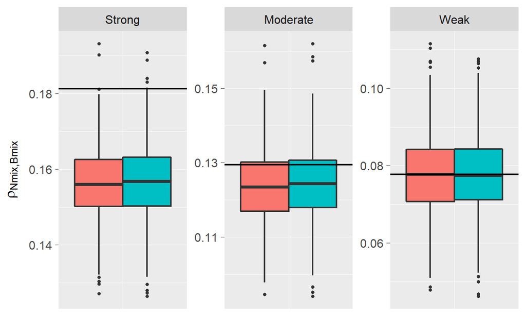

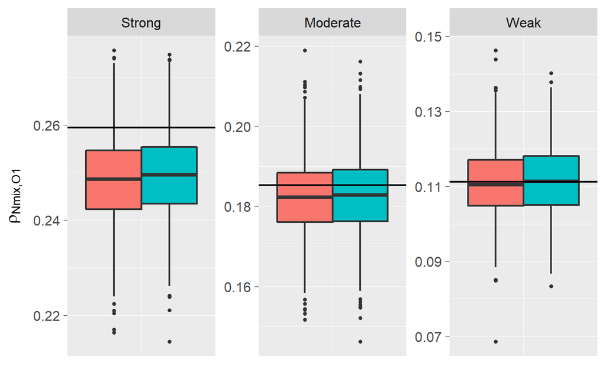

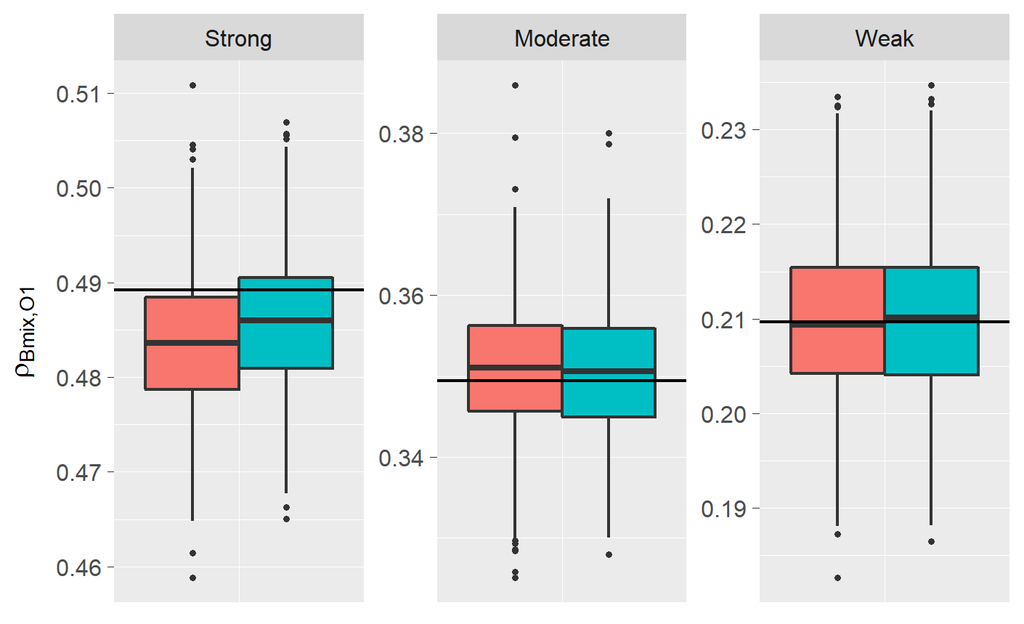

Figure 4: Boxplots of simulated correlations for continuous mixture variables (scenario A). Method 1 is in red; method 2 is in green. The horizontal lines show the approximate expected values.

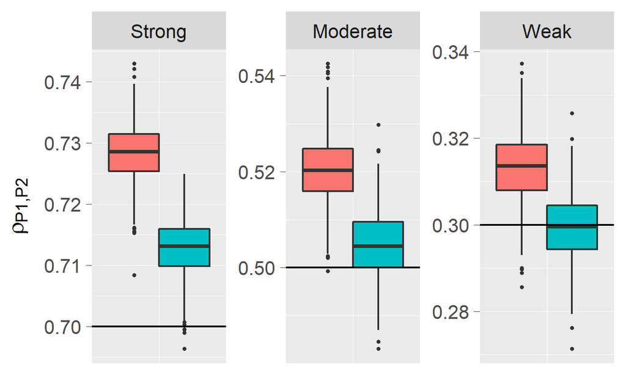

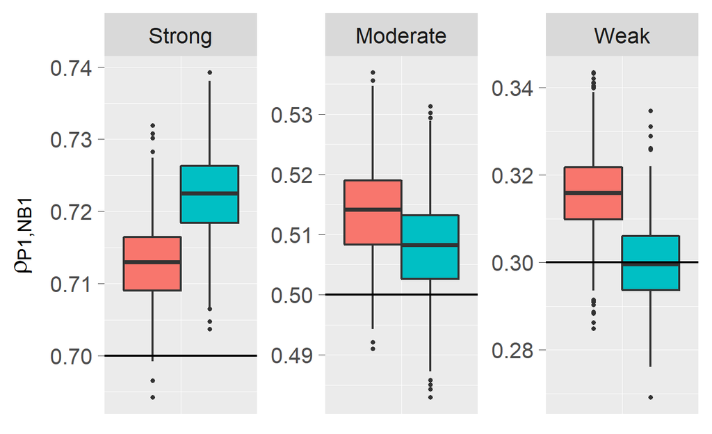

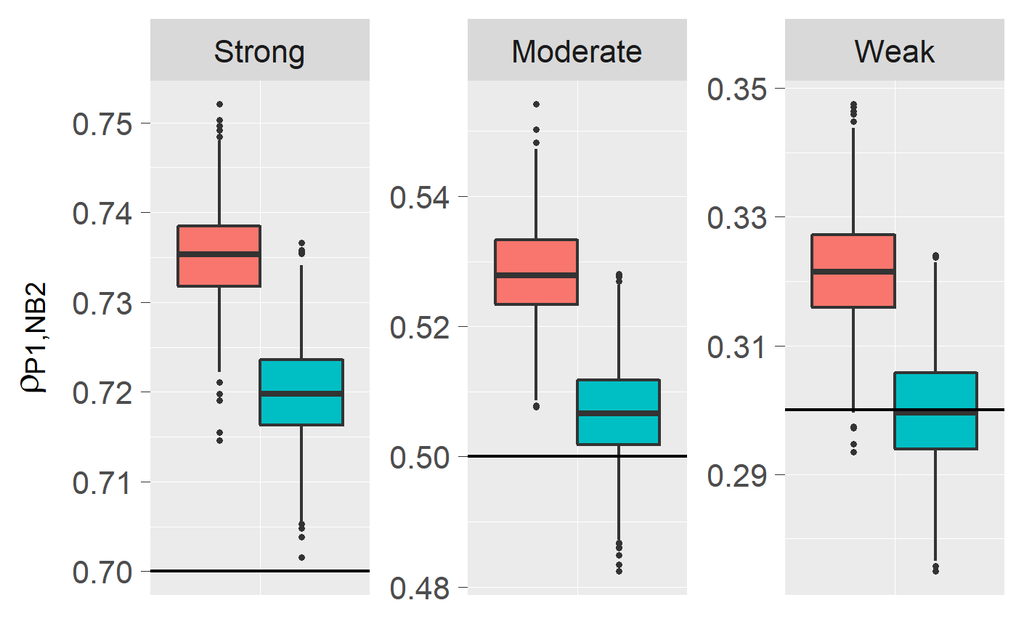

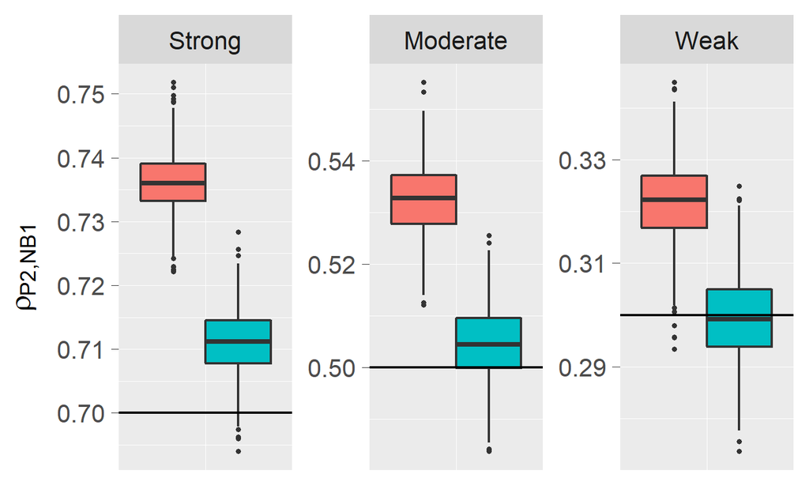

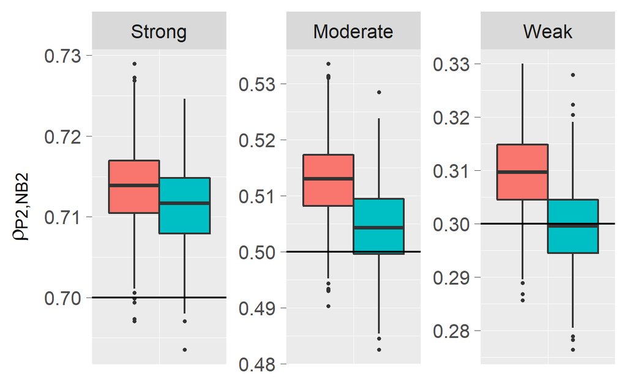

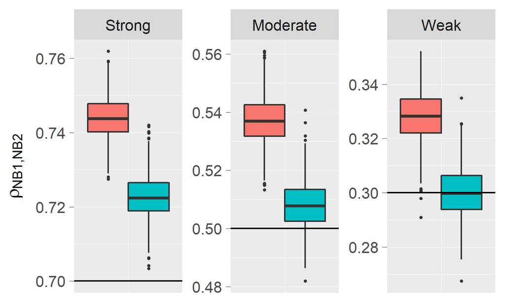

Figure 5: Boxplots of simulated correlations for P1, P2, NB1, and NB2 (scenario A). Method 1 is in red; method 2 is in green. The horizontal lines show the target values.

#### Scenario B: Ordinal, Normal and Beta mixtures, and NB variables

Tables 3 and 4 describe the target and simulated distributions for Nmix, Bmix, and NB1–NB4 in the weak correlation case. In all instances, the simulated distributions are close to the target distributions.

Table 3: Target and median (IQR) simulated distributions of continuous mixture variables.

|  | Nmix |  | Bmix |  |
| --- | --- | --- | --- | --- |
| Mean | -0.20 | -0.20 (-0.20, -0.20) | 0.70 | 0.70 (0.70, 0.70) |
| SD | 4.48 | 4.48 (4.48, 4.48) | 0.14 | 0.14 (0.14, 0.14) |
| Skew | 0.33 | 0.33 (0.32, 0.33) | -0.46 | -0.46 (-0.47, -0.45) |
| Skurtosis | -0.62 | -0.62 (-0.64, -0.61) | -0.54 | -0.54 (-0.56, -0.52) |
| Fifth | -1.02 | -1.03 (-1.07, -0.98) | 1.72 | 1.73 (1.68, 1.77) |
| Sixth | 1.49 | 1.50 (1.36, 1.62) | 0.56 | 0.54 (0.37, 0.72) |

Table 4: Target and median (IQR) simulated distributions of zero-inflated NB variables.

[output not shown]

Figure 6 shows boxplots of the simulated correlations for the count variables. The horizontal lines show the target values. Method 1 performed better for all strong correlation cases except between the two NB variables with small means (NB1 and NB2). Although method 2 had smaller errors overall, it did require considerably longer simulation times. Therefore, the user should consider using correlation method 1 when the data set contains count variables with large means. Tables 9–11 in the Appendix provide median (IQR) correlation errors for all variables and each correlation type.

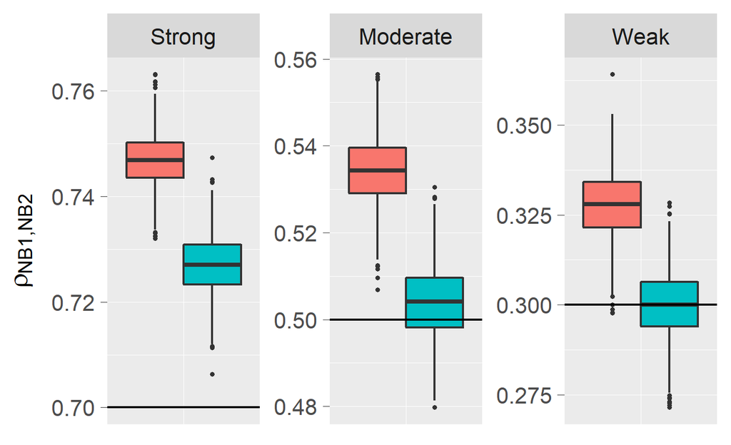

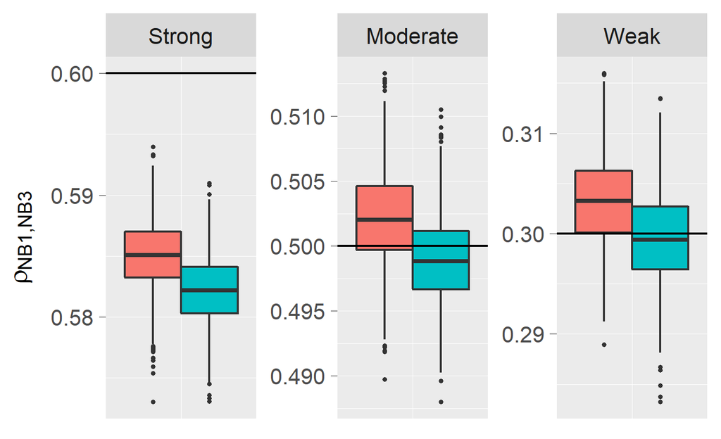

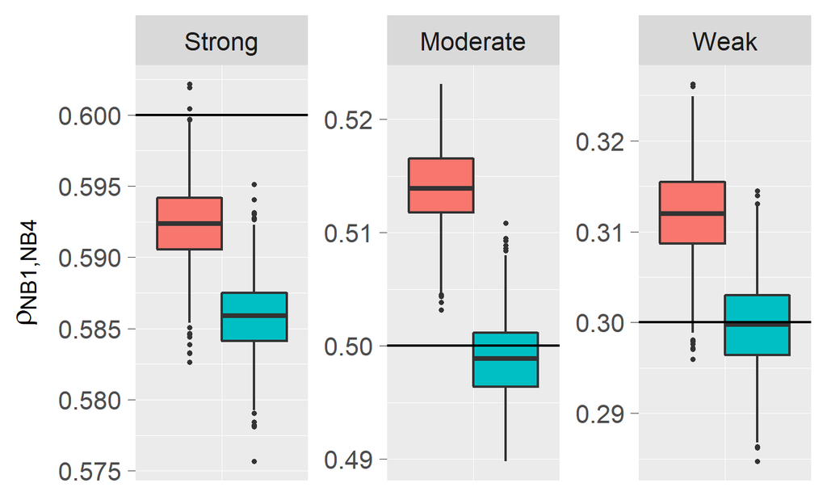

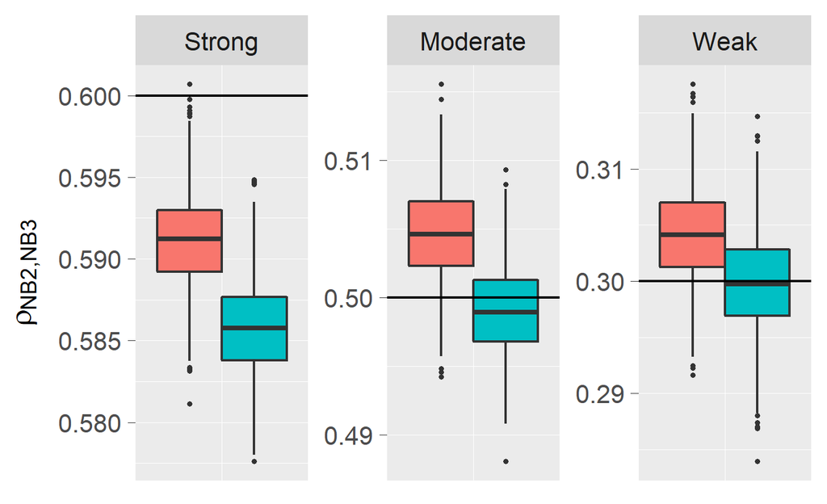

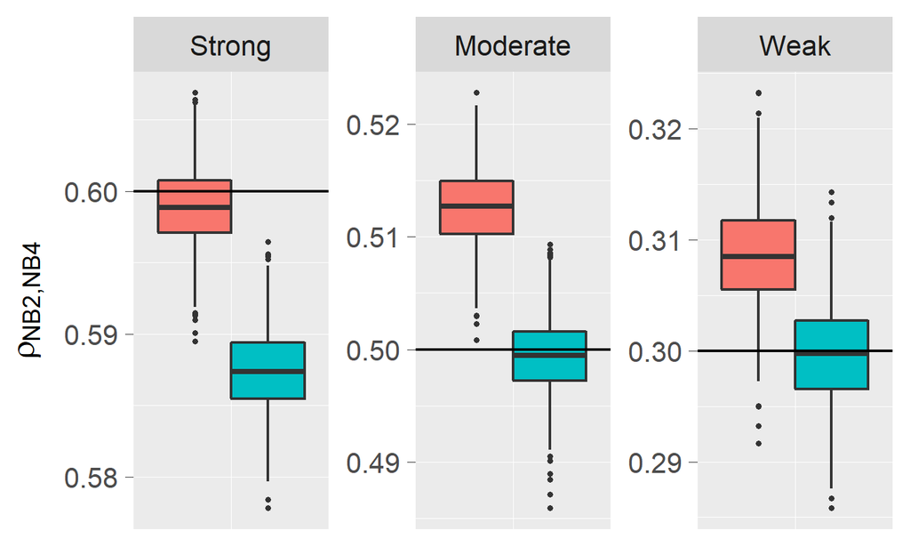

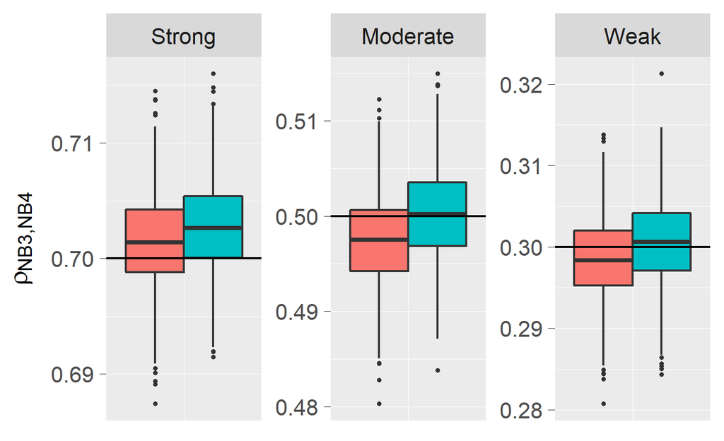

Figure 6: Boxplots of simulated correlations for NB1, NB2, NB3, and NB4 (scenario B). Method 1 is in red; method 2 is in green. The horizontal lines show the target values.

## 9 Summary

The package *SimCorrMix* generates correlated continuous (normal, non-normal, and mixture), ordinal ($r \geq 2$ categories), and count (regular or zero-inflated, Poisson or Negative Binomial) variables. It is a significant contribution to existing R simulation packages because it is the first to include continuous and count mixture variables in correlated data sets. Since *SimCorrMix* simulates variables which mimic real-world data sets and provides great flexibility, the package has a wide range of applications in clinical trial and genetic studies. The simulated data sets could be used to compare statistical methods, conduct hypothesis tests, perform bootstrapping, or calculate power. The two simulation pathways, excecuted by the functions `corrvar` and `corrvar2`, permit the user to accurately reproduce desired correlation matrices for different parameter ranges. Correlation method 1 should be used when the target distributions include count variables with large means, and correlation method 2 is preferable in opposite situations. The package also provides helper functions to calculate standardized cumulants of continuous mixture variables, approximate expected correlations with continuous mixture variables, validate parameter inputs, determine feasible correlation boundaries, and summarize simulation results numerically and graphically. Future extensions of the package include adding more variable types (e.g., zero-inflated Binomial, Gaussian, and Gamma).

## 10 Supplementary Material

The article’s supplementary file contains replication code for the examples in the paper and 8.

## Acknowledgments

This research serves as part of Allison Fialkowski’s dissertation, which was made possible by grant $T32HL079888$ from the National Heart, Lung, and Blood Institute of the National Institute of Health, USA and Dr. Hemant K. Tiwari’s William "Student" Sealy Gosset Professorship Endowment. I would like to thank my dissertation mentor, Hemant K. Tiwari, PhD; and committee members T. Mark Beasley, PhD; Charles R. Katholi, PhD; Nita A. Limdi, PhD; M. Ryan Irvin, PhD; and Nengjun Yi, PhD.

## 11 Appendix

### 11.1 Derivation of expected cumulants of continuous mixture variables

Suppose the goal is to simulate a continuous mixture variable $Y$ with PDF $h_{Y}(y)$ that contains two component distributions $Y_a$ and $Y_b$ with mixing parameters $\pi_a$ and $\pi_b$:
$$\label{System3} h_{Y}\left(y\right) = \pi_a f_{Y_a}\left(y\right) + \pi_b g_{Y_b}\left(y\right),\ y\ \in\ \mathbf{Y},\ \pi_a\ \in\ \left(0,\ 1\right),\ \pi_b\ \in\ \left(0,\ 1\right),\ \pi_a + \pi_b = 1.
\tag{33}$$
Here,
$$\label{System4}
Y_a = \sigma_a Z_a' + \mu_a,\ Y_a \sim f_{Y_a}\left(y\right),\ y\ \in\ \mathbf{Y_a} \ \ \textrm{and} \ \ Y_b = \sigma_b Z_b' + \mu_b,\ Y_b \sim g_{Y_b}\left(y\right),\ y\ \in\ \mathbf{Y_b}
\tag{34}$$
so that $Y_a$ and $Y_b$ have expected values $\mu_a$ and $\mu_b$ and variances $\sigma_a^2$ and $\sigma_b^2$. Assume the variables $Z_a'$ and $Z_b'$ are generated with zero mean and unit variance using Headrick’s fifth-order PMT given the specified values for skew $\left(\gamma_{1_a}',\ \gamma_{1_b}'\right)$, skurtosis $\left(\gamma_{2_a}',\ \gamma_{2_b}'\right)$, and standardized fifth $\left(\gamma_{3_a}',\ \gamma_{3_b}'\right)$ and sixth $\left(\gamma_{4_a}',\ \gamma_{4_b}'\right)$ cumulants. The $r^{th}$ expected value of $Y$ can be expressed as:
$$\label{System6}
\begin{split}
\mathbb{E}\left[Y^r\right] &= \int y^r h_{Y}\left(y\right) dy = \pi_a \int y^r f_{Y_a}\left(y\right) dy + \pi_b \int y^r g_{Y_b}\left(y\right) dy \\
&= \pi_a \mathbb{E}\left[Y_a^r\right] + \pi_b \mathbb{E}\left[Y_b^r\right].
\end{split} \tag{35}$$
Equation (35) can be used to derive expressions for the mean, variance, skew, skurtosis, and standardized fifth and sixth cumulants of $Y$ in terms of the $r^{th}$ expected values of $Y_a$ and $Y_b$.

1. Mean: Using $r = 1$ in Equation (35) yields $\mu$:
   $$\label{System7}
   \begin{split}
   \mathbb{E}\left[Y\right] &= \pi_a \mathbb{E}\left[Y_a\right] + \pi_b \mathbb{E}\left[Y_b\right] = \pi_a \mathbb{E}\left[\sigma_a Z_a' + \mu_a\right] + \pi_b \mathbb{E}\left[\sigma_b Z_b' + \mu_b\right] \\
   &= \pi_a \left(\sigma_a \mathbb{E}\left[Z_a'\right] + \mu_a\right) + \pi_b \left(\sigma_b \mathbb{E}\left[Z_b'\right] + \mu_b\right).
   \end{split} \tag{36}$$
   Since $\mathbb{E}\left[Z_a'\right] = \mathbb{E}\left[Z_b'\right] = 0$, this becomes:
   $$\label{System7b} \mathbb{E}\left[Y\right] = \pi_a \mu_a + \pi_b \mu_b.
   \tag{37}$$
2. Variance: The variance of $Y$ can be expressed by the relation $\textrm{Var}\left[Y\right] = \mathbb{E}\left[Y^2\right] - {\left(\mathbb{E}\left[Y\right]\right)}^2$. Using $r = 2$ in Equation (35) yields ${\mu}_{2}$:
   $$\label{System8}
   \begin{split}
   \mathbb{E}\left[Y^2\right] &= \pi_a \mathbb{E}\left[Y_a^2\right] + \pi_b \mathbb{E}\left[Y_b^2\right] = \pi_a \mathbb{E}\left[{\left(\sigma_a Z_a' + \mu_a\right)}^2\right] + \pi_b \mathbb{E}\left[{\left(\sigma_b Z_b' + \mu_b\right)}^2\right] \\
   &= \pi_a \mathbb{E}\left[\sigma_a^2 {Z_a'}^2 + 2\mu_a\sigma_a Z_a' + \mu_a^2\right] + \pi_b \mathbb{E}\left[\sigma_b^2 {Z_b'}^2 + 2\mu_b\sigma_bZ_b' + \mu_b^2\right] \\
   &= \!\begin{multlined}[t]
   \pi_a \left(\sigma_a^2 \mathbb{E}\left[{Z_a'}^2\right] + 2\mu_a\sigma_a\mathbb{E}\left[Z_a'\right] + \mu_a^2\right) \\
   + \pi_b \left(\sigma_b^2 \mathbb{E}\left[{Z_b'}^2\right] + 2\mu_b\sigma_b\mathbb{E}\left[Z_b'\right] + \mu_b^2\right).
   \end{multlined}
   \end{split} \tag{38}$$
   Applying the variance relation to $Z_a'$ and $Z_b'$ gives:
   $$\label{System9}
   \begin{split}
   \mathbb{E}\left[{Z_a'}^2\right] &= \textrm{Var}\left[Z_a'\right] + {\left(\mathbb{E}\left[Z_a'\right]\right)}^2 \\
   \mathbb{E}\left[{Z_b'}^2\right] &= \textrm{Var}\left[Z_b'\right] + {\left(\mathbb{E}\left[Z_b'\right]\right)}^2.
   \end{split} \tag{39}$$
   Since $\mathbb{E}\left[Z_a'\right] = \mathbb{E}\left[Z_b'\right] = 0$ and $\textrm{Var}\left[Z_a'\right] = \textrm{Var}\left[Z_b'\right] = 1$, $\mathbb{E}\left[{Z_a'}^2\right]$ and $\mathbb{E}\left[{Z_b'}^2\right]$ both equal $1$. Therefore, Equation (38) simplifies to:
   $$\label{System9b} \mathbb{E}\left[Y^2\right] = \pi_a \left(\sigma_a^2 + \mu_a^2\right) + \pi_b \left(\sigma_b^2 + \mu_b^2\right),
   \tag{40}$$
   and the variance of $Y$ is given by:
   $$\label{System9c} \textrm{Var}\left[Y\right] = \pi_a \left(\sigma_a^2 + \mu_a^2\right) + \pi_b \left(\sigma_b^2 + \mu_b^2\right) - \left[\pi_a \mu_a + \pi_b \mu_b\right]^2.
   \tag{41}$$
3. Skew: Using $r = 3$ in Equation (35) yields ${\mu}_{3}$:
   $$\label{System10}
   \begin{split}
   \mathbb{E}\left[Y^3\right] &= \pi_a \mathbb{E}\left[Y_a^3\right] + \pi_b \mathbb{E}\left[Y_b^3\right] = \pi_a \mathbb{E}\left[{\left(\sigma_a Z_a' + \mu_a\right)}^3\right] + \pi_b \mathbb{E}\left[{\left(\sigma_b Z_b' + \mu_b\right)}^3\right] \\
   &= \!\begin{multlined}[t]
   \pi_a \mathbb{E}\left[\sigma_a^3 {Z_a'}^3 + 3\sigma_a^2\mu_a{Z_a'}^2 + 3\sigma_a\mu_a^2 Z_a' + \mu_a^3\right] \\
   + \pi_b \mathbb{E}\left[\sigma_b^3 {Z_b'}^3 + 3\sigma_b^2\mu_b{Z_b'}^2 + 3\sigma_b\mu_b^2 Z_b' + \mu_b^3\right]
   \end{multlined}\\
   &= \!\begin{multlined}[t]
   \pi_a \left(\sigma_a^3 \mathbb{E}\left[{Z_a'}^3\right] + 3\sigma_a^2\mu_a\mathbb{E}\left[{Z_a'}^2\right] + 3\sigma_a\mu_a^2\mathbb{E}\left[Z_a'\right] + \mu_a^3\right)\\
   + \pi_b \left(\sigma_b^3 \mathbb{E}\left[{Z_b'}^3\right] + 3\sigma_b^2\mu_b\mathbb{E}\left[{Z_b'}^2\right] + 3\sigma_b\mu_b^2 \mathbb{E}\left[Z_b'\right] + \mu_b^3\right).
   \end{multlined}
   \end{split}
   \tag{42}$$
   Then $\mathbb{E}\left[{Z_a'}^3\right] = {\mu}_{3_a}'$ and $\mathbb{E}\left[{Z_b'}^3\right] = {\mu}_{3_b}'$ are given by:
   $$\label{System11}
   \begin{split}
   \mathbb{E}\left[{Z_a'}^3\right] &= {\left(\textrm{Var}\left[Z_a'\right]\right)}^{3/2} \gamma_{1_a}' = \gamma_{1_a}' \\
   \mathbb{E}\left[{Z_b'}^3\right] &= {\left(\textrm{Var}\left[Z_b'\right]\right)}^{3/2} \gamma_{1_b}' = \gamma_{1_b}'.
   \end{split} \tag{43}$$
   Combining these with $\mathbb{E}\left[Z_a'\right] = \mathbb{E}\left[Z_b'\right] = 0$ and $\mathbb{E}\left[{Z_a'}^2\right] = \mathbb{E}\left[{Z_b'}^2\right] = 1$, Equation (42) simplifies to:
   $$\label{System11b} \mathbb{E}\left[Y^3\right] = \pi_a \left(\sigma_a^3 \gamma_{1_a}' + 3\sigma_a^2\mu_a + \mu_a^3\right) + \pi_b \left(\sigma_b^3 \gamma_{1_b}' + 3\sigma_b^2\mu_b + \mu_b^3\right).
   \tag{44}$$
   From Equation (7), the skew of $Y$ is given by:
   $$\label{System11c} \gamma_{1} = \frac{\pi_a \left(\sigma_a^3 \gamma_{1_a}' + 3\sigma_a^2\mu_a + \mu_a^3\right) + \pi_b \left(\sigma_b^3 \gamma_{1_b}' + 3\sigma_b^2\mu_b + \mu_b^3\right)}{{\left(\pi_a \left(\sigma_a^2 + \mu_a^2\right) + \pi_b \left(\sigma_b^2 + \mu_b^2\right) - \left[\pi_a \mu_a + \pi_b \mu_b\right]^2\right)}^{3/2}}.
   \tag{45}$$
4. Skurtosis: Using $r = 4$ in Equation (35) yields ${\mu}_{4}$:
   $$\label{System12}
   \begin{split}
   \mathbb{E}\left[Y^4\right] &= \pi_a \mathbb{E}\left[Y_{a}^4\right] + \pi_b \mathbb{E}\left[Y_{b}^4\right] = \pi_a \mathbb{E}\left[{\left(\sigma_{a} Z_{a}' + \mu_{a}\right)}^4\right] + \pi_b \mathbb{E}\left[{\left(\sigma_{b} Z_{b}' + \mu_{b}\right)}^4\right] \\
   &= \!\begin{multlined}[t]
   \pi_a \mathbb{E}\left[\sigma_{a}^4 {Z_{a}'}^4 + 4\sigma_{a}^3\mu_{a}{Z_{a}'}^3 + 6\sigma_{a}^2\mu_{a}^2{Z_{a}'}^2 + 4\sigma_{a}\mu_{a}^3 Z_{a}' + \mu_{a}^4\right] \\
   + \pi_b \mathbb{E}\left[\sigma_{b}^4 {Z_{b}'}^4 + 4\sigma_{b}^3\mu_{b}{Z_{b}'}^3 + 6\sigma_{b}^2\mu_{b}^2{Z_{b}'}^2 + 4\sigma_{b}\mu_{b}^3 Z_{b}' + \mu_{b}^4\right]
   \end{multlined}\\
   &= \pi_a \Big(\sigma_{a}^4 \mathbb{E}\left[{Z_{a}'}^4\right] + 4\sigma_{a}^3\mu_{a}\mathbb{E}\left[{Z_{a}'}^3\right] + 6\sigma_{a}^2\mu_{a}^2\mathbb{E}\left[{Z_{a}'}^2\right] + 4\sigma_{a}\mu_{a}^3 \mathbb{E}\left[Z_{a}'\right] + \mu_{a}^4\Big) \\
   &\qquad \ \ + \pi_b \Big(\sigma_{b}^4 \mathbb{E}\left[{Z_{b}'}^4\right] + 4\sigma_{b}^3\mu_{b}\mathbb{E}\left[{Z_{b}'}^3\right] + 6\sigma_{b}^2\mu_{b}^2\mathbb{E}\left[{Z_{b}'}^2\right] + 4\sigma_{b}\mu_{b}^3 \mathbb{E}\left[Z_{b}'\right] + \mu_{b}^4\Big) \\
   \end{split} \tag{46}$$
   Then $\mathbb{E}\left[{Z_{a}'}^4\right] = {\mu}_{4_{a}}'$ and $\mathbb{E}\left[{Z_{b}'}^4\right] = {\mu}_{4_{b}}'$ are given by:
   $$\label{System13}
   \begin{split}
   \mathbb{E}\left[{Z_{a}'}^4\right] &= {\left(\textrm{Var}\left[Z_{a}'\right]\right)}^2 \left(\gamma_{2_{a}}' + 3\right) = \gamma_{2_{a}}' + 3 \\
   \mathbb{E}\left[{Z_{b}'}^4\right] &= {\left(\textrm{Var}\left[Z_{b}'\right]\right)}^2 \left(\gamma_{2_{b}}' + 3\right) = \gamma_{2_{b}}' + 3.
   \end{split} \tag{47}$$
   Since $\mathbb{E}\left[Z_{a}'\right] = \mathbb{E}\left[Z_{b}'\right] = 0$ and $\mathbb{E}\left[{Z_{a}'}^2\right] = \mathbb{E}\left[{Z_{b}'}^2\right] = 1$, Equation (46) simplifies to:
   $$\label{System14}
   \begin{split}
   \mathbb{E}\left[Y^4\right] &= \!\begin{multlined}[t]
   \pi_a \left[\sigma_{a}^4\left(\gamma_{2_{a}}' + 3\right) + 4\sigma_{a}^3\mu_{a}\gamma_{1_{a}}' + 6\sigma_{a}^2\mu_{a}^2 + \mu_{a}^4\right] \\
   + \pi_b \left[\sigma_{b}^4\left(\gamma_{2_{b}}' + 3\right) + 4\sigma_{b}^3\mu_{b}\gamma_{1_{b}}' + 6\sigma_{b}^2\mu_{b}^2 + \mu_{b}^4\right].
   \end{multlined}
   \end{split} \tag{48}$$
   From Equation (8), the skurtosis of $Y$ is given by:
   $$\label{System15}
   \begin{split}
   \gamma_{2} &= \!\begin{multlined}[t]
   \frac{\pi_a \left[\sigma_{a}^4\left(\gamma_{2_{a}}' + 3\right) + 4\sigma_{a}^3\mu_{a}\gamma_{1_{a}}' + 6\sigma_{a}^2\mu_{a}^2 + \mu_{a}^4\right]}{{\left(\pi_a \left(\sigma_a^2 + \mu_a^2\right) + \pi_b \left(\sigma_b^2 + \mu_b^2\right) - \left[\pi_a \mu_a + \pi_b \mu_b\right]^2\right)}^2} \\
   + \frac{\pi_b \left[\sigma_{b}^4\left(\gamma_{2_{b}}' + 3\right) + 4\sigma_{b}^3\mu_{b}\gamma_{1_{b}}' + 6\sigma_{b}^2\mu_{b}^2 + \mu_{b}^4\right]}{{\left(\pi_a \left(\sigma_a^2 + \mu_a^2\right) + \pi_b \left(\sigma_b^2 + \mu_b^2\right) - \left[\pi_a \mu_a + \pi_b \mu_b\right]^2\right)}^2}.
   \end{multlined}
   \end{split} \tag{49}$$
5. Standardized fifth cumulant: Using $r = 5$ in Equation (35) yields ${\mu}_{5}$:
   $$\label{System16}
   \begin{split}
   \mathbb{E}\left[Y^5\right] &= \pi_a \mathbb{E}\left[Y_{a}^5\right] + \pi_b \mathbb{E}\left[Y_{b}^5\right] = \pi_a \mathbb{E}\left[{\left(\sigma_{a} Z_{a}' + \mu_{a}\right)}^5\right] + \pi_b \mathbb{E}\left[{\left(\sigma_{b} Z_{b}' + \mu_{b}\right)}^5\right] \\
   &= \pi_a \mathbb{E}\Big[\sigma_{a}^5 {Z_{a}'}^5 + 5\sigma_{a}^4\mu_{a}{Z_{a}'}^4 + 10\sigma_{a}^3\mu_{a}^2{Z_{a}'}^3 + 10\sigma_{a}^2\mu_{a}^3{Z_{a}'}^2 + 5\sigma_{a}\mu_{a}^4 Z_{a}' + \mu_{a}^5\Big] \\
   &\qquad \ \ + \pi_b \mathbb{E}\Big[\sigma_{b}^5 {Z_{b}'}^5 + 5\sigma_{b}^4\mu_{b}{Z_{b}'}^4 + 10\sigma_{b}^3\mu_{b}^2{Z_{b}'}^3 + 10\sigma_{b}^2\mu_{b}^3{Z_{b}'}^2 + 5\sigma_{b}\mu_{b}^4 Z_{b}' + \mu_{b}^5\Big] \\
   &= \pi_a \Big(\sigma_{a}^5 \mathbb{E}\left[{Z_{a}'}^5\right] + 5\sigma_{a}^4\mu_{a}\mathbb{E}\left[{Z_{a}'}^4\right] + 10\sigma_{a}^3\mu_{a}^2\mathbb{E}\left[{Z_{a}'}^3\right] \\
   &\qquad \ \ \qquad \ \ + 10\sigma_{a}^2\mu_{a}^3\mathbb{E}\left[{Z_{a}'}^2\right] + 5\sigma_{a}\mu_{a}^4 \mathbb{E}\left[Z_{a}'\right] + \mu_{a}^5\Big)\\
   &\qquad \ \ + \pi_b \Big(\sigma_{b}^5 \mathbb{E}\left[{Z_{b}'}^5\right] + 5\sigma_{b}^4\mu_{b}\mathbb{E}\left[{Z_{b}'}^4\right] + 10\sigma_{b}^3\mu_{b}^2\mathbb{E}\left[{Z_{b}'}^3\right] \\
   &\qquad \ \ \qquad \ \ + 10\sigma_{b}^2\mu_{b}^3\mathbb{E}\left[{Z_{b}'}^2\right] + 5\sigma_{b}\mu_{b}^4 \mathbb{E}\left[Z_{b}'\right] + \mu_{b}^5\Big).
   \end{split} \tag{50}$$
   Then $\mathbb{E}\left[{Z_{a}'}^5\right] = {\mu}_{5_{a}}'$ and $\mathbb{E}\left[{Z_{b}'}^5\right] = {\mu}_{5_{b}}'$ are given by:
   $$\label{System17}
   \begin{split}
   \mathbb{E}\left[{Z_{a}'}^5\right] &= {\left(\textrm{Var}\left[Z_{a}'\right]\right)}^{5/2} \left(\gamma_{3_{a}}' + 10\gamma_{1_{a}}'\right) = \gamma_{3_{a}}' + 10\gamma_{1_{a}}' \\
   \mathbb{E}\left[{Z_{b}'}^5\right] &= {\left(\textrm{Var}\left[Z_{b}'\right]\right)}^{5/2} \left(\gamma_{3_{b}}' + 10\gamma_{1_{b}}'\right) = \gamma_{3_{b}}' + 10\gamma_{1_{b}}'.
   \end{split} \tag{51}$$
   Since $\mathbb{E}\left[Z_{a}'\right] = \mathbb{E}\left[Z_{b}'\right] = 0$ and $\mathbb{E}\left[{Z_{a}'}^2\right] =$ $\mathbb{E}\left[{Z_{b}'}^2\right] = 1$, Equation (50) simplifies to:
   $$\label{System18}
   \begin{split}
   \mathbb{E}\left[Y^5\right] &= \pi_a \left[\sigma_{a}^5\left(\gamma_{3_{a}}' + 10\gamma_{1_{a}}'\right) + 5\sigma_{a}^4\mu_{a}\left(\gamma_{2_{a}}' + 3\right) + 10\sigma_{a}^3\mu_{a}^2\gamma_{1_{a}}' + 10\sigma_{a}^2\mu_{a}^3 + \mu_{a}^5\right] \\
   &\ \ \ \ + \pi_b \left[\sigma_{b}^5\left(\gamma_{3_{b}}' + 10\gamma_{1_{b}}'\right) + 5\sigma_{b}^4\mu_{b}\left(\gamma_{2_{b}}' + 3\right) + 10\sigma_{b}^3\mu_{b}^2\gamma_{1_{b}}' + 10\sigma_{b}^2\mu_{b}^3 + \mu_{b}^5\right].
   \end{split} \tag{52}$$
   From Equation (9), the standardized fifth cumulant of $Y$ is given by:
   $$\label{System19}
   \begin{split}
   \gamma_{3} &= \frac{\pi_a \left[\sigma_{a}^5\left(\gamma_{3_{a}}' + 10\gamma_{1_{a}}'\right) + 5\sigma_{a}^4\mu_{a}\left(\gamma_{2_{a}}' + 3\right) + 10\sigma_{a}^3\mu_{a}^2\gamma_{1_{a}}' + 10\sigma_{a}^2\mu_{a}^3 + \mu_{a}^5\right]}{{\left(\pi_a \left(\sigma_a^2 + \mu_a^2\right) + \pi_b \left(\sigma_b^2 + \mu_b^2\right) - \left[\pi_a \mu_a + \pi_b \mu_b\right]^2\right)}^{5/2}} \\
   &\ \ \ \ + \frac{\pi_b \left[\sigma_{b}^5\left(\gamma_{3_{b}}' + 10\gamma_{1_{b}}'\right) + 5\sigma_{b}^4\mu_{b}\left(\gamma_{2_{b}}' + 3\right) + 10\sigma_{b}^3\mu_{b}^2\gamma_{1_{b}}' + 10\sigma_{b}^2\mu_{b}^3 + \mu_{b}^5\right]}{{\left(\pi_a \left(\sigma_a^2 + \mu_a^2\right) + \pi_b \left(\sigma_b^2 + \mu_b^2\right) - \left[\pi_a \mu_a + \pi_b \mu_b\right]^2\right)}^{5/2}} - 10{\gamma}_{1}.
   \end{split} \tag{53}$$
6. Standardized sixth cumulant: Using $r = 6$ in Equation (35) yields ${\mu}_{6}$:
   $$\begin{split}
   \mathbb{E}\left[Y^6\right] &= \pi_a \mathbb{E}\left[Y_{a}^6\right] + \pi_b \mathbb{E}\left[Y_{b}^6\right] = \pi_a \mathbb{E}\left[{\left(\sigma_{a} Z_{a}' + \mu_{a}\right)}^6\right] + \pi_b \mathbb{E}\left[{\left(\sigma_{b} Z_{b}' + \mu_{b}\right)}^6\right] \\
   &= \pi_a \mathbb{E}\Big[\sigma_{a}^6 {Z_{a}'}^6 + 6\sigma_{a}^5\mu_{a}{Z_{a}'}^5 + 15\sigma_{a}^4\mu_{a}^2{Z_{a}'}^4 + 20\sigma_{a}^3\mu_{a}^3{Z_{a}'}^3 \\
   &\qquad \ \ \qquad \ \ + 15\sigma_{a}^2\mu_{a}^4{Z_{a}'}^2 + 6\sigma_{a}\mu_{a}^5 Z_{a}' + \mu_{a}^6\Big] \\
   &\qquad \ \ + \pi_b \mathbb{E}\Big[\sigma_{b}^6 {Z_{b}'}^6 + 6\sigma_{b}^5\mu_{b}{Z_{b}'}^5 + 15\sigma_{b}^4\mu_{b}^2{Z_{b}'}^4 + 20\sigma_{b}^3\mu_{b}^3{Z_{b}'}^3 \\
   &\qquad \ \ \qquad \ \ + 15\sigma_{b}^2\mu_{b}^4{Z_{b}'}^2 + 6\sigma_{b}\mu_{b}^5 Z_{b}' + \mu_{b}^6\Big] \\
   \end{split} \nonumber$$

   $$\label{System20}
   \begin{split}
   &= \pi_a \Big(\sigma_{a}^6 \mathbb{E}\left[{Z_{a}'}^6\right] + 6\sigma_{a}^5\mu_{a}\mathbb{E}\left[{Z_{a}'}^5\right] + 15\sigma_{a}^4\mu_{a}^2\mathbb{E}\left[{Z_{a}'}^4\right] + 20\sigma_{a}^3\mu_{a}^3\mathbb{E}\left[{Z_{a}'}^3\right] \\
   &\qquad \ \ \qquad \ \ + 15\sigma_{a}^2\mu_{a}^4\mathbb{E}\left[{Z_{a}'}^2\right] + 6\sigma_{a}\mu_{a}^5 \mathbb{E}\left[Z_{a}'\right] + \mu_{a}^6\Big) \\
   &\qquad \ \ + \pi_b \Big(\sigma_{b}^6 \mathbb{E}\left[{Z_{b}'}^6\right] + 6\sigma_{b}^5\mu_{b}\mathbb{E}\left[{Z_{b}'}^5\right] + 15\sigma_{b}^4\mu_{b}^2\mathbb{E}\left[{Z_{b}'}^4\right] + 20\sigma_{b}^3\mu_{b}^3\mathbb{E}\left[{Z_{b}'}^3\right] \\
   &\qquad \ \ \qquad \ \ + 15\sigma_{b}^2\mu_{b}^4\mathbb{E}\left[{Z_{b}'}^2\right] + 6\sigma_{b}\mu_{b}^5 \mathbb{E}\left[Z_{b}'\right] + \mu_{b}^6\Big).
   \end{split} \tag{54}$$
   Then $\mathbb{E}\left[{Z_{a}'}^6\right] = {\mu}_{6_{a}}'$ and $\mathbb{E}\left[{Z_{b}'}^6\right] = {\mu}_{6_{b}}'$ are given by:
   $$\label{System21}
   \begin{split}
   \mathbb{E}\left[{Z_{a}'}^6\right] &= {\left(\textrm{Var}\left[Z_{a}'\right]\right)}^3 \left(\gamma_{4_{a}}' + 15\gamma_{2_{a}}' + 10{\gamma_{1_{a}}'}^2 + 15\right) = \gamma_{4_{a}}' + 15\gamma_{2_{a}}' + 10{\gamma_{1_{a}}'}^2 + 15 \\
   \mathbb{E}\left[{Z_{b}'}^6\right] &= {\left(\textrm{Var}\left[Z_{b}'\right]\right)}^3 \left(\gamma_{4_{b}}' + 15\gamma_{2_{b}}' + 10{\gamma_{1_{b}}'}^2 + 15\right) = \gamma_{4_{b}}' + 15\gamma_{2_{b}}' + 10{\gamma_{1_{b}}'}^2 + 15.
   \end{split} \tag{55}$$
   Since $\mathbb{E}\left[Z_{a}'\right] = \mathbb{E}\left[Z_{b}'\right] = 0$ and $\mathbb{E}\left[{Z_{a}'}^2\right] = \mathbb{E}\left[{Z_{b}'}^2\right] = 1$, Equation (54) simplifies to:
   $$\label{System22}
   \begin{split}
   \mathbb{E}\left[Y^6\right] &= \pi_a \Big[\sigma_{a}^6\left(\gamma_{4_{a}}' + 15\gamma_{2_{a}}' + 10{\gamma_{1_{a}}'}^2 + 15\right) + 6\sigma_{a}^5\mu_{a}\left(\gamma_{3_{a}}' + 10\gamma_{1_{a}}'\right) \\
   &\qquad \ \ \qquad \ \ + 15\sigma_{a}^4\mu_{a}^2\left(\gamma_{2_{a}}' + 3\right) + 20\sigma_{a}^3\mu_{a}^3\gamma_{1_{a}}' + 15\sigma_{a}^2\mu_{a}^4 + \mu_{a}^6\Big] \\
   &\qquad \ \ + \pi_b \Big[\sigma_{b}^6\left(\gamma_{4_{b}}' + 15\gamma_{2_{b}}' + 10{\gamma_{1_{b}}'}^2 + 15\right) + 6\sigma_{b}^5\mu_{b}\left(\gamma_{3_{b}}' + 10\gamma_{1_{b}}'\right) \\
   &\qquad \ \ \qquad \ \ + 15\sigma_{b}^4\mu_{b}^2\left(\gamma_{2_{b}}' + 3\right) + 20\sigma_{b}^3\mu_{b}^3\gamma_{1_{b}}' + 15\sigma_{b}^2\mu_{b}^4 + \mu_{b}^6\Big].
   \end{split} \tag{56}$$
   From Equation (10), the standardized sixth cumulant of $Y$ is given by:
   $$\label{System23}
   \begin{split}
   \gamma_{4} &= \frac{\pi_a \Big[\sigma_{a}^6\left(\gamma_{4_{a}}' + 15\gamma_{2_{a}}' + 10{\gamma_{1_{a}}'}^2 + 15\right) + 6\sigma_{a}^5\mu_{a}\left(\gamma_{3_{a}}' + 10\gamma_{1_{a}}'\right)}{{\left(\pi_a \left(\sigma_a^2 + \mu_a^2\right) + \pi_b \left(\sigma_b^2 + \mu_b^2\right) - \left[\pi_a \mu_a + \pi_b \mu_b\right]^2\right)}^3} \\
   &\qquad \ \ \qquad \ \ \frac{+ 15\sigma_{a}^4\mu_{a}^2\left(\gamma_{2_{a}}' + 3\right) + 20\sigma_{a}^3\mu_{a}^3\gamma_{1_{a}}' + 15\sigma_{a}^2\mu_{a}^4 + \mu_{a}^6\Big]}{{\left(\pi_a \left(\sigma_a^2 + \mu_a^2\right) + \pi_b \left(\sigma_b^2 + \mu_b^2\right) - \left[\pi_a \mu_a + \pi_b \mu_b\right]^2\right)}^3} \\
   &\qquad \ \ + \frac{\pi_b \Big[\sigma_{b}^6\left(\gamma_{4_{b}}' + 15\gamma_{2_{b}}' + 10{\gamma_{1_{b}}'}^2 + 15\right) + 6\sigma_{b}^5\mu_{b}\left(\gamma_{3_{b}}' + 10\gamma_{1_{b}}'\right)}{{\left(\pi_a \left(\sigma_a^2 + \mu_a^2\right) + \pi_b \left(\sigma_b^2 + \mu_b^2\right) - \left[\pi_a \mu_a + \pi_b \mu_b\right]^2\right)}^3} \\
   &\qquad \ \ \qquad \ \ \frac{+ 15\sigma_{b}^4\mu_{b}^2\left(\gamma_{2_{b}}' + 3\right)+ 20\sigma_{b}^3\mu_{b}^3\gamma_{1_{b}}' + 15\sigma_{b}^2\mu_{b}^4 + \mu_{b}^6\Big]}{{\left(\pi_a \left(\sigma_a^2 + \mu_a^2\right) + \pi_b \left(\sigma_b^2 + \mu_b^2\right) - \left[\pi_a \mu_a + \pi_b \mu_b\right]^2\right)}^3} \\
   &\qquad \ \ - 15{\gamma}_{2} - 10{{\gamma}_{1}}^{2} - 15.
   \end{split} \tag{57}$$

### 11.2 Results from examples comparing correlation methods 1 and 2

Table 5: Table numbers for matrices of correlation errors.

|  | Scenario |  |
| --- | --- | --- |
| Correlation Type | A: Poisson and NB | B: NB |
| Strong | 6 | 9 |
| Moderate | 7 | 10 |
| Weak | 8 | 11 |

Table 6: Median (IQR) of correlation errors using correlation methods 1 (in black) and 2 (in blue) with strong correlations in scenario A.

|  | O1 | N1 | N2 | N3 | B1 |
| --- | --- | --- | --- | --- | --- |
| O1 | 0 | -0.08 (-0.083, -0.078) | -0.08 (-0.082, -0.078) | -0.08 (-0.082, -0.078) | -0.036 (-0.039, -0.034) |
| N1 | -0.078 (-0.08, -0.076) | 0 | 0.153 (0.152, 0.153) | 0.153 (0.152, 0.153) | -0.164 (-0.164, -0.164) |
| N2 | -0.078 (-0.08, -0.076) | 0.153 (0.153, 0.153) | 0 | 0.153 (0.152, 0.153) | -0.164 (-0.164, -0.164) |
| N3 | -0.078 (-0.081, -0.076) | 0.153 (0.153, 0.153) | 0.153 (0.153, 0.153) | 0 | -0.164 (-0.164, -0.164) |
| B1 | -0.034 (-0.036, -0.031) | -0.164 (-0.164, -0.164) | -0.164 (-0.164, -0.164) | -0.164 (-0.164, -0.164) | 0 |
| B2 | -0.035 (-0.037, -0.033) | -0.165 (-0.166, -0.165) | -0.166 (-0.166, -0.165) | -0.166 (-0.166, -0.165) | 0.155 (0.154, 0.156) |
| P1 | -0.033 (-0.036, -0.03) | -0.157 (-0.16, -0.153) | -0.156 (-0.159, -0.153) | -0.156 (-0.159, -0.153) | -0.123 (-0.125, -0.12) |
| P2 | -0.018 (-0.02, -0.015) | -0.133 (-0.135, -0.13) | -0.133 (-0.135, -0.13) | -0.133 (-0.135, -0.13) | -0.097 (-0.1, -0.095) |
| NB1 | -0.05 (-0.053, -0.047) | -0.168 (-0.172, -0.165) | -0.168 (-0.171, -0.165) | -0.168 (-0.171, -0.165) | -0.137 (-0.14, -0.134) |
| NB2 | -0.028 (-0.031, -0.025) | -0.156 (-0.16, -0.153) | -0.156 (-0.159, -0.153) | -0.156 (-0.159, -0.153) | -0.125 (-0.128, -0.122) |
|  | B2 | P1 | P2 | NB1 | NB2 |
| O1 | -0.038 (-0.04, -0.035) | -0.023 (-0.025, -0.02) | 0.003 (0, 0.005) | -0.053 (-0.056, -0.05) | -0.043 (-0.046, -0.04) |
| N1 | -0.166 (-0.167, -0.165) | -0.156 (-0.159, -0.153) | -0.128 (-0.131, -0.126) | -0.166 (-0.169, -0.163) | -0.153 (-0.156, -0.15) |
| N2 | -0.166 (-0.167, -0.165) | -0.156 (-0.158, -0.153) | -0.128 (-0.131, -0.126) | -0.166 (-0.17, -0.163) | -0.153 (-0.156, -0.15) |
| N3 | -0.166 (-0.167, -0.165) | -0.156 (-0.159, -0.153) | -0.128 (-0.131, -0.126) | -0.166 (-0.17, -0.163) | -0.153 (-0.156, -0.15) |
| B1 | 0.154 (0.153, 0.155) | -0.123 (-0.126, -0.12) | -0.093 (-0.096, -0.091) | -0.135 (-0.138, -0.132) | -0.121 (-0.124, -0.118) |
| B2 | 0 | -0.156 (-0.159, -0.154) | -0.121 (-0.123, -0.118) | -0.174 (-0.177, -0.171) | -0.157 (-0.16, -0.155) |
| P1 | -0.156 (-0.159, -0.153) | 0 | 0.029 (0.025, 0.031) | 0.013 (0.009, 0.016) | 0.035 (0.032, 0.038) |
| P2 | -0.124 (-0.126, -0.122) | 0.013 (0.01, 0.016) | 0 | 0.036 (0.033, 0.039) | 0.014 (0.01, 0.017) |
| NB1 | -0.175 (-0.178, -0.172) | 0.022 (0.018, 0.026) | 0.011 (0.008, 0.015) | 0 | 0.044 (0.04, 0.048) |
| NB2 | -0.161 (-0.164, -0.158) | 0.02 (0.016, 0.024) | 0.012 (0.008, 0.015) | 0.022 (0.019, 0.027) | 0 |

Table 7: Median (IQR) of correlation errors using correlation methods 1 (in black) and 2 (in blue) with moderate correlations in scenario A.

|  | O1 | N1 | N2 | N3 | B1 |
| --- | --- | --- | --- | --- | --- |
| O1 | 0 | -0.021 (-0.023, -0.018) | -0.021 (-0.023, -0.018) | -0.021 (-0.023, -0.018) | 0 (-0.003, 0.003) |
| N1 | -0.019 (-0.022, -0.017) | 0 | 0.049 (0.049, 0.05) | 0.049 (0.049, 0.05) | -0.035 (-0.035, -0.035) |
| N2 | -0.019 (-0.022, -0.016) | 0.051 (0.051, 0.051) | 0 | 0.049 (0.049, 0.05) | -0.035 (-0.035, -0.035) |
| N3 | -0.019 (-0.022, -0.017) | 0.051 (0.051, 0.051) | 0.051 (0.051, 0.051) | 0 | -0.035 (-0.035, -0.035) |
| B1 | -0.001 (-0.003, 0.002) | -0.034 (-0.034, -0.034) | -0.034 (-0.034, -0.033) | -0.034 (-0.034, -0.033) | 0 |
| B2 | -0.001 (-0.003, 0.002) | -0.034 (-0.035, -0.033) | -0.034 (-0.035, -0.033) | -0.034 (-0.035, -0.033) | 0.016 (0.015, 0.017) |
| P1 | -0.002 (-0.005, 0.001) | -0.041 (-0.045, -0.038) | -0.041 (-0.044, -0.038) | -0.041 (-0.044, -0.038) | -0.009 (-0.012, -0.006) |
| P2 | -0.001 (-0.005, 0.002) | -0.034 (-0.037, -0.032) | -0.034 (-0.037, -0.032) | -0.034 (-0.037, -0.032) | -0.006 (-0.009, -0.003) |
| NB1 | -0.004 (-0.007, 0) | -0.044 (-0.048, -0.041) | -0.045 (-0.048, -0.041) | -0.044 (-0.048, -0.041) | -0.011 (-0.014, -0.008) |
| NB2 | -0.003 (-0.006, 0) | -0.041 (-0.044, -0.037) | -0.041 (-0.044, -0.037) | -0.041 (-0.044, -0.038) | -0.01 (-0.012, -0.007) |
|  | B2 | P1 | P2 | NB1 | NB2 |
| O1 | 0.001 (-0.002, 0.003) | 0 (-0.004, 0.004) | 0.005 (0.001, 0.008) | -0.009 (-0.013, -0.006) | -0.007 (-0.011, -0.004) |
| N1 | -0.035 (-0.036, -0.034) | -0.038 (-0.041, -0.035) | -0.031 (-0.034, -0.028) | -0.04 (-0.043, -0.037) | -0.037 (-0.04, -0.034) |
| N2 | -0.035 (-0.036, -0.034) | -0.038 (-0.041, -0.035) | -0.031 (-0.034, -0.029) | -0.04 (-0.044, -0.037) | -0.037 (-0.04, -0.033) |
| N3 | -0.035 (-0.036, -0.034) | -0.038 (-0.041, -0.035) | -0.031 (-0.034, -0.028) | -0.041 (-0.044, -0.037) | -0.037 (-0.04, -0.034) |
| B1 | 0.013 (0.012, 0.014) | -0.005 (-0.008, -0.002) | -0.003 (-0.006, 0) | -0.006 (-0.01, -0.003) | -0.005 (-0.008, -0.002) |
| B2 | 0 | -0.027 (-0.029, -0.024) | -0.019 (-0.022, -0.017) | -0.033 (-0.035, -0.03) | -0.029 (-0.031, -0.027) |
| P1 | -0.03 (-0.033, -0.028) | 0 | 0.02 (0.016, 0.025) | 0.014 (0.008, 0.019) | 0.028 (0.023, 0.033) |
| P2 | -0.022 (-0.024, -0.019) | 0.004 (0, 0.009) | 0 | 0.033 (0.028, 0.037) | 0.013 (0.008, 0.017) |
| NB1 | -0.037 (-0.04, -0.034) | 0.008 (0.003, 0.013) | 0.004 (0, 0.01) | 0 | 0.037 (0.032, 0.042) |
| NB2 | -0.033 (-0.036, -0.03) | 0.007 (0.002, 0.012) | 0.004 (0, 0.009) | 0.008 (0.002, 0.013) | 0 |

Table 8: Median (IQR) of correlation errors using correlation methods 1 (in black) and 2 (in blue) with weak correlations in scenario A.

|  | O1 | N1 | N2 | N3 | B1 |
| --- | --- | --- | --- | --- | --- |
| O1 | 0 | 0 (-0.003, 0.003) | 0 (-0.003, 0.003) | 0 (-0.003, 0.003) | 0 (-0.003, 0.003) |
| N1 | 0 (-0.003, 0.003) | 0 | 0 (0, 0) | 0 (0, 0) | 0 (0, 0) |
| N2 | 0 (-0.003, 0.003) | 0 (0, 0) | 0 | 0 (0, 0) | 0 (0, 0) |
| N3 | 0 (-0.003, 0.003) | 0 (0, 0) | 0 (0, 0) | 0 | 0 (0, 0) |
| B1 | 0 (-0.003, 0.003) | 0 (0, 0) | 0 (0, 0) | 0 (0, 0) | 0 |
| B2 | 0 (-0.003, 0.004) | 0 (-0.001, 0.001) | 0 (-0.001, 0.001) | 0 (-0.001, 0.001) | 0 (-0.001, 0.001) |
| P1 | 0 (-0.004, 0.004) | 0 (-0.004, 0.004) | 0 (-0.004, 0.003) | 0 (-0.004, 0.004) | -0.001 (-0.004, 0.002) |
| P2 | 0 (-0.004, 0.004) | 0 (-0.003, 0.003) | 0 (-0.003, 0.003) | 0 (-0.003, 0.003) | 0 (-0.003, 0.003) |
| NB1 | -0.001 (-0.005, 0.003) | 0 (-0.004, 0.004) | 0 (-0.004, 0.004) | 0 (-0.004, 0.004) | -0.001 (-0.005, 0.002) |
| NB2 | -0.001 (-0.005, 0.003) | 0 (-0.004, 0.003) | 0 (-0.003, 0.003) | 0 (-0.004, 0.003) | -0.002 (-0.005, 0.002) |
|  | B2 | P1 | P2 | NB1 | NB2 |
| O1 | 0 (-0.003, 0.003) | 0 (-0.004, 0.004) | 0 (-0.004, 0.004) | -0.002 (-0.006, 0.002) | -0.002 (-0.005, 0.002) |
| N1 | 0 (-0.001, 0.001) | 0 (-0.004, 0.004) | 0 (-0.003, 0.003) | 0 (-0.004, 0.004) | 0 (-0.004, 0.004) |
| N2 | 0 (-0.001, 0.001) | 0 (-0.003, 0.004) | 0 (-0.003, 0.003) | 0 (-0.004, 0.004) | 0 (-0.003, 0.004) |
| N3 | 0 (-0.001, 0.001) | 0 (-0.004, 0.004) | 0 (-0.003, 0.003) | 0 (-0.004, 0.004) | 0 (-0.004, 0.003) |
| B1 | 0 (-0.001, 0.001) | -0.001 (-0.004, 0.003) | -0.001 (-0.004, 0.002) | -0.001 (-0.005, 0.002) | -0.001 (-0.005, 0.002) |
| B2 | 0 | -0.009 (-0.012, -0.006) | -0.006 (-0.009, -0.003) | -0.011 (-0.014, -0.008) | -0.01 (-0.013, -0.006) |
| P1 | -0.009 (-0.012, -0.006) | 0 | 0.014 (0.008, 0.018) | 0.016 (0.01, 0.022) | 0.021 (0.016, 0.027) |
| P2 | -0.006 (-0.009, -0.004) | 0 (-0.006, 0.004) | 0 | 0.022 (0.017, 0.027) | 0.01 (0.004, 0.015) |
| NB1 | -0.011 (-0.014, -0.008) | 0 (-0.006, 0.006) | -0.001 (-0.006, 0.005) | 0 | 0.028 (0.022, 0.035) |
| NB2 | -0.01 (-0.013, -0.006) | 0 (-0.006, 0.006) | 0 (-0.006, 0.005) | 0 (-0.006, 0.006) | 0 |

Table 9: Median (IQR) of correlation errors using correlation methods 1 (in black) and 2 (in blue) with strong correlations in scenario B.

|  | O1 | N1 | N2 | N3 | B1 |
| --- | --- | --- | --- | --- | --- |
| O1 | 0 | -0.095 (-0.097, -0.092) | -0.095 (-0.097, -0.092) | -0.095 (-0.097, -0.093) | -0.049 (-0.051, -0.046) |
| N1 | -0.094 (-0.096, -0.092) | 0 | 0.141 (0.141, 0.141) | 0.141 (0.141, 0.141) | -0.172 (-0.172, -0.172) |
| N2 | -0.094 (-0.096, -0.092) | 0.141 (0.141, 0.141) | 0 | 0.141 (0.141, 0.141) | -0.172 (-0.172, -0.171) |
| N3 | -0.094 (-0.096, -0.092) | 0.141 (0.141, 0.141) | 0.141 (0.141, 0.141) | 0 | -0.172 (-0.172, -0.172) |
| B1 | -0.048 (-0.05, -0.046) | -0.172 (-0.172, -0.171) | -0.172 (-0.172, -0.171) | -0.172 (-0.172, -0.171) | 0 |
| B2 | -0.049 (-0.051, -0.047) | -0.173 (-0.174, -0.172) | -0.173 (-0.174, -0.172) | -0.173 (-0.174, -0.172) | 0.14 (0.139, 0.141) |
| NB1 | -0.056 (-0.059, -0.053) | -0.161 (-0.164, -0.158) | -0.16 (-0.164, -0.157) | -0.161 (-0.164, -0.158) | -0.129 (-0.132, -0.126) |
| NB2 | -0.033 (-0.036, -0.03) | -0.151 (-0.154, -0.148) | -0.151 (-0.154, -0.148) | -0.151 (-0.154, -0.148) | -0.118 (-0.121, -0.115) |
| NB3 | -0.001 (-0.003, 0) | -0.094 (-0.096, -0.092) | -0.094 (-0.096, -0.092) | -0.094 (-0.096, -0.092) | -0.052 (-0.054, -0.051) |
| NB4 | 0.001 (-0.002, 0.003) | -0.099 (-0.101, -0.098) | -0.1 (-0.101, -0.097) | -0.1 (-0.102, -0.098) | -0.056 (-0.057, -0.054) |
|  | B2 | NB1 | NB2 | NB3 | NB4 |
| O1 | -0.05 (-0.052, -0.048) | -0.05 (-0.053, -0.047) | -0.04 (-0.043, -0.037) | -0.011 (-0.013, -0.009) | 0.022 (0.02, 0.024) |
| N1 | -0.173 (-0.174, -0.172) | -0.158 (-0.161, -0.155) | -0.148 (-0.151, -0.145) | -0.094 (-0.096, -0.092) | -0.095 (-0.097, -0.093) |
| N2 | -0.173 (-0.174, -0.172) | -0.158 (-0.161, -0.155) | -0.148 (-0.151, -0.145) | -0.094 (-0.096, -0.092) | -0.095 (-0.097, -0.093) |
| N3 | -0.173 (-0.174, -0.172) | -0.158 (-0.162, -0.155) | -0.148 (-0.151, -0.145) | -0.094 (-0.096, -0.092) | -0.095 (-0.097, -0.093) |
| B1 | 0.14 (0.138, 0.141) | -0.126 (-0.129, -0.124) | -0.115 (-0.118, -0.112) | -0.052 (-0.054, -0.05) | -0.051 (-0.053, -0.05) |
| B2 | 0 | -0.166 (-0.169, -0.163) | -0.151 (-0.154, -0.149) | -0.042 (-0.044, -0.039) | -0.045 (-0.047, -0.042) |
| NB1 | -0.168 (-0.171, -0.165) | 0 | 0.047 (0.043, 0.05) | -0.015 (-0.017, -0.013) | -0.008 (-0.009, -0.006) |
| NB2 | -0.155 (-0.157, -0.152) | 0.027 (0.023, 0.031) | 0 | -0.009 (-0.011, -0.007) | -0.001 (-0.003, 0.001) |
| NB3 | -0.042 (-0.045, -0.04) | -0.018 (-0.02, -0.016) | -0.014 (-0.016, -0.012) | 0 | 0.001 (-0.001, 0.004) |
| NB4 | -0.049 (-0.051, -0.046) | -0.014 (-0.016, -0.012) | -0.013 (-0.015, -0.011) | 0.003 (0, 0.005) | 0 |

Table 10: Median (IQR) of correlation errors using correlation methods 1 (in black) and 2 (in blue) with moderate correlations in scenario B.

|  | O1 | N1 | N2 | N3 | B1 |
| --- | --- | --- | --- | --- | --- |
| O1 | 0 | -0.02 (-0.023, -0.017) | -0.02 (-0.023, -0.017) | -0.02 (-0.023, -0.017) | 0.002 (-0.001, 0.004) |
| N1 | -0.019 (-0.022, -0.017) | 0 | 0.038 (0.038, 0.038) | 0.038 (0.038, 0.038) | -0.043 (-0.043, -0.042) |
| N2 | -0.02 (-0.022, -0.017) | 0.039 (0.039, 0.039) | 0 | 0.038 (0.038, 0.038) | -0.043 (-0.043, -0.042) |
| N3 | -0.019 (-0.022, -0.017) | 0.039 (0.039, 0.039) | 0.039 (0.039, 0.039) | 0 | -0.043 (-0.043, -0.042) |
| B1 | 0.001 (-0.001, 0.004) | -0.042 (-0.042, -0.042) | -0.042 (-0.042, -0.042) | -0.042 (-0.042, -0.042) | 0 |
| B2 | 0.002 (-0.001, 0.004) | -0.042 (-0.043, -0.041) | -0.042 (-0.043, -0.041) | -0.042 (-0.043, -0.041) | 0.017 (0.016, 0.018) |
| NB1 | 0 (-0.004, 0.003) | -0.029 (-0.033, -0.025) | -0.029 (-0.033, -0.026) | -0.029 (-0.032, -0.026) | -0.001 (-0.004, 0.003) |
| NB2 | 0 (-0.003, 0.003) | -0.028 (-0.031, -0.024) | -0.027 (-0.03, -0.024) | -0.027 (-0.03, -0.025) | -0.001 (-0.004, 0.002) |
| NB3 | 0 (-0.003, 0.003) | -0.015 (-0.017, -0.013) | -0.015 (-0.017, -0.013) | -0.015 (-0.017, -0.013) | -0.001 (-0.003, 0.001) |
| NB4 | 0 (-0.003, 0.003) | -0.016 (-0.018, -0.014) | -0.016 (-0.018, -0.014) | -0.016 (-0.018, -0.014) | 0 (-0.002, 0.002) |
|  | B2 | NB1 | NB2 | NB3 | NB4 |
| O1 | 0.002 (-0.001, 0.005) | -0.008 (-0.011, -0.004) | -0.006 (-0.009, -0.003) | -0.002 (-0.005, 0.001) | 0.008 (0.004, 0.011) |
| N1 | -0.043 (-0.044, -0.042) | -0.027 (-0.031, -0.024) | -0.026 (-0.029, -0.022) | -0.015 (-0.017, -0.013) | -0.015 (-0.017, -0.012) |
| N2 | -0.043 (-0.044, -0.042) | -0.027 (-0.031, -0.024) | -0.025 (-0.029, -0.022) | -0.015 (-0.017, -0.013) | -0.014 (-0.017, -0.012) |
| N3 | -0.043 (-0.044, -0.042) | -0.027 (-0.031, -0.024) | -0.026 (-0.029, -0.023) | -0.015 (-0.017, -0.013) | -0.015 (-0.017, -0.012) |
| B1 | 0.018 (0.017, 0.019) | 0 (-0.004, 0.003) | -0.001 (-0.004, 0.002) | -0.001 (-0.003, 0.001) | -0.001 (-0.003, 0.002) |
| B2 | 0 | -0.028 (-0.031, -0.024) | -0.025 (-0.027, -0.022) | 0.005 (0.003, 0.008) | 0.003 (0.001, 0.006) |
| NB1 | -0.027 (-0.031, -0.025) | 0 | 0.034 (0.029, 0.04) | 0.002 (0, 0.005) | 0.014 (0.012, 0.017) |
| NB2 | -0.025 (-0.027, -0.022) | 0.004 (-0.002, 0.01) | 0 | 0.005 (0.002, 0.007) | 0.013 (0.01, 0.015) |
| NB3 | 0.005 (0.003, 0.008) | -0.001 (-0.003, 0.001) | -0.001 (-0.003, 0.001) | 0 | -0.002 (-0.006, 0.001) |
| NB4 | 0.005 (0.002, 0.007) | -0.001 (-0.004, 0.001) | -0.001 (-0.003, 0.002) | 0 (-0.003, 0.004) | 0 |

Table 11: Median (IQR) of correlation errors using correlation methods 1 (in black) and 2 (in blue) with weak correlations in scenario B.

|  | O1 | N1 | N2 | N3 | B1 |
| --- | --- | --- | --- | --- | --- |
| O1 | 0 | 0 (-0.003, 0.003) | 0 (-0.003, 0.003) | 0 (-0.003, 0.003) | 0 (-0.003, 0.003) |
| N1 | 0 (-0.003, 0.003) | 0 | 0 (0, 0) | 0 (0, 0) | 0 (0, 0) |
| N2 | 0 (-0.003, 0.003) | 0 (0, 0) | 0 | 0 (0, 0) | 0 (0, 0) |
| N3 | -0.001 (-0.003, 0.003) | 0 (0, 0) | 0 (0, 0) | 0 | 0 (0, 0) |
| B1 | 0 (-0.003, 0.003) | 0 (0, 0) | 0 (0, 0) | 0 (0, 0) | 0 |
| B2 | 0 (-0.003, 0.003) | 0 (-0.001, 0.001) | 0 (-0.001, 0.001) | 0 (-0.001, 0.001) | 0 (-0.001, 0.001) |
| NB1 | -0.001 (-0.005, 0.003) | 0 (-0.004, 0.004) | 0 (-0.004, 0.004) | 0 (-0.004, 0.004) | -0.002 (-0.005, 0.002) |
| NB2 | -0.001 (-0.005, 0.003) | 0 (-0.004, 0.003) | 0 (-0.003, 0.003) | 0 (-0.004, 0.003) | -0.002 (-0.005, 0.002) |
| NB3 | 0 (-0.004, 0.003) | 0 (-0.002, 0.002) | 0 (-0.002, 0.002) | 0 (-0.002, 0.002) | 0 (-0.002, 0.003) |
| NB4 | 0.001 (-0.003, 0.004) | 0 (-0.002, 0.002) | 0 (-0.002, 0.003) | 0 (-0.002, 0.002) | 0.001 (-0.002, 0.003) |
|  | B2 | NB1 | NB2 | NB3 | NB4 |
| O1 | 0 (-0.003, 0.003) | -0.002 (-0.006, 0.002) | -0.002 (-0.005, 0.003) | 0 (-0.004, 0.003) | 0.001 (-0.002, 0.005) |
| N1 | 0 (-0.001, 0.001) | 0 (-0.003, 0.004) | 0 (-0.003, 0.003) | 0 (-0.002, 0.002) | 0 (-0.002, 0.002) |
| N2 | 0 (-0.001, 0.001) | 0 (-0.004, 0.004) | 0 (-0.004, 0.003) | 0 (-0.002, 0.002) | 0 (-0.002, 0.002) |
| N3 | 0 (-0.001, 0.001) | 0 (-0.004, 0.004) | 0 (-0.004, 0.003) | 0 (-0.002, 0.002) | 0 (-0.002, 0.002) |
| B1 | 0 (-0.001, 0.001) | -0.002 (-0.005, 0.002) | -0.002 (-0.005, 0.002) | 0 (-0.002, 0.002) | 0 (-0.002, 0.003) |
| B2 | 0 | -0.011 (-0.014, -0.007) | -0.01 (-0.012, -0.007) | 0.002 (0, 0.005) | 0.002 (-0.001, 0.005) |
| NB1 | -0.011 (-0.014, -0.007) | 0 | 0.028 (0.021, 0.034) | 0.003 (0, 0.006) | 0.012 (0.009, 0.015) |
| NB2 | -0.01 (-0.013, -0.007) | 0 (-0.006, 0.006) | 0 | 0.004 (0.001, 0.007) | 0.008 (0.006, 0.012) |
| NB3 | 0.003 (0, 0.005) | -0.001 (-0.004, 0.003) | 0 (-0.003, 0.003) | 0 | -0.002 (-0.005, 0.002) |
| NB4 | 0.002 (-0.001, 0.005) | 0 (-0.004, 0.003) | 0 (-0.003, 0.003) | 0.001 (-0.003, 0.004) | 0 |

### 11.3 Supplementary materials

Supplementary materials are available in addition to this article. It can be downloaded at RJ-2019-022.zip

### 11.4 CRAN packages used

AdaptGauss, DPP, bgmm, ClusterR, mclust, mixture, AdMit, bimixt, bmixture, CAMAN, flexmix, mixdist, mixtools, nspmix, MixtureInf, Rmixmod, hurdlr, zic, mixpack, distr, stats, rebmix, SimCorrMix, SimMultiCorrData, GenOrd, VGAM, Matrix, ggplot2, mvtnorm

### 11.5 CRAN Task Views implied by cited packages

Bayesian, ChemPhys, Cluster, Distributions, Econometrics, Environmetrics, ExtremeValue, Finance, MissingData, NetworkAnalysis, NumericalMathematics, Optimization, Phylogenetics, Psychometrics, Robust, Spatial, TeachingStatistics

A. Amatya and H. Demirtas. Simultaneous generation of multivariate mixed data with Poisson and normal marginals. *Journal of Statistical Computation and Simulation*, 85(15): 3129–3139, 2015. URL https://doi.org/10.1080/00949655.2014.953534.

D. Ardia. *AdMit: Adaptive mixture of student-t distributions.* 2017. URL https://CRAN.R-project.org/package=AdMit. R package version 2.1.3.

L. M. Avila, M. R. May and J. Ross-Ibarra. *DPP: Inference of parameters of normal distributions from a mixture of normals.* 2017. URL https://CRAN.R-project.org/package=DPP. R package version 0.1.1.

A. A. Baghban, A. Pourhoseingholi, F. Zayeri, A. A. Jafari and S. M. Alavian. Application of zero-inflated Poisson mixed models in prognostic factors of Hepatitis C. *BioMed Research International*, 2013. URL https://doi.org/10.1155/2013/403151.

O. G. Bahcall. Complex traits: Genetic discovery, heritability and prediction. *Nature Reviews Genetics*, 16(257): 2015. URL https://doi.org/10.1038/nrg3947.

E. Balderama and T. Trippe. *Hurdlr: Zero-inflated and hurdle modelling using bayesian inference.* 2017. URL https://CRAN.R-project.org/package=hurdlr. R package version 0.1.

A. Barbiero and P. A. Ferrari. *GenOrd: Simulation of discrete random variables with given correlation matrix and marginal distributions.* 2015a. URL https://CRAN.R-project.org/package=GenOrd. R package version 1.4.0.

A. Barbiero and P. A. Ferrari. Simulation of correlated Poisson variables. *Applied Stochastic Models in Business and Industry*, 31: 669–680, 2015b. URL https://doi.org/10.1002/asmb.2072.

D. Bates and M. Maechler. *Matrix: Sparse and dense matrix classes and methods.* 2017. URL https://CRAN.R-project.org/package=Matrix. R package version 1.2-12.

M. Bhattacharjee, M. S. Rajeevan and M. J. Sillanpää. Prediction of complex human diseases from pathway-focused candidate markers by joint estimation of marker effects: Case of chronic fatigue syndrome. *Human Genomics*, 9(1): 8, 2015. URL https://doi.org/10.1186/s40246-015-0030-6.

P. Biecek and E. Szczurek. *Bgmm: Gaussian mixture modeling algorithms and the belief-based mixture modeling.* 2017. URL https://CRAN.R-project.org/package=bgmm. R package version 1.8.3.

N. Bouguila, D. Ziou and E. Monga. Practical Bayesian estimation of a finite beta mixture through Gibbs sampling and its applications. *Statistics and Computing*, 16: 215–225, 2006. URL https://doi.org/10.1007/s11222-006-8451-7.

R. P. Browne, A. ElSherbiny and P. D. McNicholas. *Mixture: Mixture models for clustering and classification.* 2015. URL https://CRAN.R-project.org/package=mixture. R package version 1.4.

M. Comas-Cufí, J. A. Martín-Fernández and G. Mateu-Figueras. *Mixpack: Tools to work with mixture components.* 2017. URL https://CRAN.R-project.org/package=mixpack. R package version 0.3.6.

H. Dai and R. Charnigo. Compound hierarchical correlated beta mixture with an application to cluster mouse transcription factor DNA binding data. *Biostatistics (Oxford, England)*, 16(4): 641–654, 2015. URL http://doi.org/10.1093/biostatistics/kxv016.

X. Dai, T. Erkkilä, O. Yli-Harja and H. Lähdesmäki. A joint finite mixture model for clustering genes from independent Gaussian and beta distributed data. *BMC Bioinformatics*, 10(1): 165, 2009. URL https://doi.org/10.1186/1471-2105-10-165.

J. Davenport, J. Bezder and R. Hathaway. Parameter estimation for finite mixture distributions. *Computers & Mathematics with Applications*, 15(10): 819–828, 1988.

H. Demirtas and D. Hedeker. A practical way for computing approximate lower and upper correlation bounds. *The American Statistician*, 65(2): 104–109, 2011. URL https://doi.org/10.1198/tast.2011.10090.

H. Demirtas, D. Hedeker and R. J. Mermelstein. Simulation of massive public health data by power polynomials. *Statistics in Medicine*, 31(27): 3337–3346, 2012. URL https://doi.org/10.1002/sim.5362.

R. C. Elston, J. M. Olson and L. Palmer. *Biostatistical genetics and genetic epidemiology.* Hoboken, New Jersey: John Wiley & Sons, 2002.

L. J. Emrich and M. R. Piedmonte. A method for generating high-dimensional multivariate binary variates. *The American Statistician*, 45: 302–304, 1991. URL https://doi.org/10.1080/00031305.1991.10475828.

B. S. Everitt. An introduction to finite mixture distributions. *Statistical Methods in Medical Research*, 5(2): 107–127, 1996. URL https://doi.org/10.1177/096228029600500202.

P. A. Ferrari and A. Barbiero. Simulating ordinal data. *Multivariate Behavioral Research*, 47(4): 566–589, 2012. URL https://doi.org/10.1080/00273171.2012.692630.

A. C. Fialkowski. *SimMultiCorrData: Simulation of correlated data with multiple variable types.* 2017. URL https://CRAN.R-project.org/package=SimMultiCorrData. R package version 0.2.1.

A. C. Fialkowski and H. K. Tiwari. SimMultiCorrData: An R package for simulation of correlated non-normal or normal, binary, ordinal, poisson, and negative binomial variables. *Manuscript submitted for publication*, 2017.

R. A. Fisher. Moments and product moments of sampling distributions. *Proceedings of the London Mathematical Society Series 2*, 30: 199–238, 1929.

A. I. Fleishman. A method for simulating non-normal distributions. *Psychometrika*, 43: 521–532, 1978. URL https://doi.org/10.1007/BF02293811.

C. Fraley, A. E. Raftery and L. Scrucca. *Mclust: Gaussian mixture modelling for model-based clustering, classification, and density estimation.* 2017. URL https://CRAN.R-project.org/package=mclust. R package version 5.4.

M. Fréchet. Les tableaux de corrélation et les programmes linéaires. *Revue de L’Institut International de Statistique / Review of the International Statistical Institute*, 25(1/3): 23–40, 1957. URL https://doi.org/10.2307/1401672.

B. L. Fridley, D. Serie, G. Jenkins, K. White, W. Bamlet, J. D. Potter and E. L. Goode. Bayesian mixture models for the incorporation of prior knowledge to inform genetic association studies. *Genetic Epidemiology*, 34(5): 418–426, 2010. URL https://doi.org/10.1002/gepi.20494.

R. Fu, D. K. Dey and K. E. Holsinger. A beta-mixture model for assessing genetic population structure. *Biometrics*, 67(3): 1073–1082, 2011. URL http://www.jstor.org/stable/41242556.

A. Genz and F. Bretz. *Computation of multivariate normal and t probabilities.* Heidelberg: Springer-Verlag, 2009. URL https://doi.org/10.1007/978-3-642-01689-9.

A. Genz, F. Bretz, T. Miwa, X. Mi and T. Hothorn. *Mvtnorm: Multivariate normal and t distributions.* 2017. URL https://CRAN.R-project.org/package=mvtnorm. R package version 1.0-6.

B. Gruen and F. Leisch. *Flexmix: Flexible mixture modeling.* 2017. URL https://CRAN.R-project.org/package=flexmix. R package version 2.3-14.

D. B. Hall. Zero-inflated Poisson and binomial regression with random effects: A case study. *Biometrics*, 56(4): 1030–1039, 2000. URL https://doi.org/10.1111/j.0006-341X.2000.01030.x.

H. He, W. Tang, W. Wang and P. Crits-Christoph. Structural zeroes and zero-inflated models. *Shanghai Archives of Psychiatry*, 26(4): 236–242, 2014. URL https://doi.org/10.3969/j.issn.1002-0829.2014.04.008.

T. C. Headrick. Fast fifth-order polynomial transforms for generating univariate and multivariate non-normal distributions. *Computational Statistics & Data Analysis*, 40(4): 685–711, 2002. URL https://doi.org/10.1016/S0167-9473(02)00072-5.

T. C. Headrick and R. K. Kowalchuk. The power method transformation: Its probability density function, distribution function, and its further use for fitting data. *Journal of Statistical Computation and Simulation*, 77: 229–249, 2007. URL https://doi.org/10.1080/10629360600605065.

T. C. Headrick and S. S. Sawilowsky. Simulating correlated non-normal distributions: Extending the Fleishman power method. *Psychometrika*, 64: 25–35, 1999. URL https://doi.org/10.1007/BF02294317.

N. Higham. Computing the nearest correlation matrix - a problem from finance. *IMA Journal of Numerical Analysis*, 22(3): 329–343, 2002. URL https://doi.org/10.1093/imanum/22.3.329.

W. Hoeffding. Scale-invariant correlation theory. In *The collected works of wassily hoeffding*, Eds N. I. Fisher and P. K. Sen pages. 57–107 1994. New York: Springer-Verlag. URL https://doi.org/10.1007/978-1-4612-0865-5_4.

N. Ismail and H. Zamani. Estimation of claim count data using negative binomial, generalized Poisson, zero-inflated negative binomial and zero-inflated generalized Poisson regression models. *Casualty Actuarial Society E-Forum*, 41(20): 1–28, 2013.

Y. Ji, C. Wu, P. Liu, J. Wang and K. R. Coombes. Applications of beta-mixture models in bioinformatics. *Bioinformatics*, 21(9): 2118–2122, 2005. URL http://dx.doi.org/10.1093/bioinformatics/bti318.

M. Jochmann. *Zic: Bayesian inference for zero-inflated count models.* 2017. URL https://CRAN.R-project.org/package=zic. R package version 0.9.1.

M. Kendall and A. Stuart. *The advanced theory of statistics.* 4th ed New York: Macmillan, 1977.

M. Kohl. *Distr: Object oriented implementation of distributions.* 2017. URL https://CRAN.R-project.org/package=distr. R package version 2.6.2.

D. Lambert. Zero-inflated Poisson regression, with an application to defects in manufacturing. *Technometrics*, 34(1): 1–14, 1992.

F. Langrognet, R. Lebret, C. Poli and S. Iovleff. *Rmixmod: Supervised, unsupervised, semi-supervised classification with MIXture MODelling (interface of MIXMOD software).* 2016. URL https://CRAN.R-project.org/package=Rmixmod. R package version 2.1.1.

M. G. Larson and G. E. Dinse. A mixture model for the regression analysis of competing risks data. *Journal of the Royal Statistical Society. Series C (Applied Statistics)*, 34(3): 201–211, 1985. URL http://www.jstor.org/stable/2347464.

B. Lau, S. R. Cole and S. J. Gange. Competing risk regression models for epidemiologic data. *American Journal of Epidemiology*, 170(2): 244–256, 2009. URL http://dx.doi.org/10.1093/aje/kwp107.

B. Lau, S. R. Cole and S. J. Gange. Parametric mixture models to evaluate and summarize hazard ratios in the presence of competing risks with time-dependent hazards and delayed entry. *Statistics in Medicine*, 30(6): 654–665, 2011. URL http://dx.doi.org/10.1002/sim.4123.

K. Laurila, B. Oster, C. L. Andersen, P. Lamy, T. Orntoft, O. Yli-Harja and C. Wiuf. A beta-mixture model for dimensionality reduction, sample classification and analysis. *BMC Bioinformatics*, 12(1): 215, 2011. URL https://doi.org/10.1186/1471-2105-12-215.

R. R. J. Lewine. Sex differences in schizophrenia: Timing or subtypes? *Psychological Bulletin*, 90: 432–444, 1981.

S. Li, J. Chen and P. Li. *MixtureInf: Inference for finite mixture models.* 2016. URL https://CRAN.R-project.org/package=MixtureInf. R package version 1.1.

Z. Ma and A. Leijon. Bayesian estimation of beta mixture models with variational inference. *IEEE Trans Pattern Anal Mach Intell*, 33(11): 2160–2173, 2011. URL https://doi.org/10.1109/TPAMI.2011.63.

P. MacDonald and with contributions from Juan Du. *Mixdist: Finite mixture distribution models.* 2012. URL https://CRAN.R-project.org/package=mixdist. R package version 0.5-4.

G. J. McLachlan. Cluster analysis and related techniques in medical research. *Statistical Methods in Medical Research*, 1(1): 27–48, 1992. URL https://doi.org/10.1177/096228029200100103.

A. Mohammadi. *Bmixture: Bayesian estimation for finite mixture of distributions.* 2017. URL https://CRAN.R-project.org/package=bmixture. R package version 0.5.

L. Mouselimis. *ClusterR: Gaussian mixture models, k-means, mini-batch-kmeans and k-medoids clustering.* 2017. URL https://CRAN.R-project.org/package=ClusterR. R package version 1.0.9.

M. Nagode. *Rebmix: Finite mixture modeling, clustering & classification.* 2017. URL https://CRAN.R-project.org/package=rebmix. R package version 2.9.3.

S. R. Newcomer, J. F. Steiner and E. A. Bayliss. Identifying subgroups of complex patients with cluster analysis. *The American Journal of Managed Care*, 17(8): e324–32, 2011.

U. Olsson, F. Drasgow and N. J. Dorans. The polyserial correlation coefficient. *Psychometrika*, 47(3): 337–347, 1982. URL https://doi.org/10.1007/BF02294164.

L. Pamulaparty, C. V. G. Rao and M. S. Rao. Cluster analysis of medical research data using R. *Global Journal of Computer Science and Technology*, 16(1): 1–6, 2016.

R Core Team. *R: A language and environment for statistical computing.* Vienna, Austria: R Foundation for Statistical Computing, 2017. URL https://www.R-project.org/.

P. Schlattmann, J. Hoehne and M. Verba. *CAMAN: Finite mixture models and meta-analysis tools - based on c.a.MAN.* 2016. URL https://CRAN.R-project.org/package=CAMAN. R package version 0.74.

N. J. Schork, D. B. Allison and B. Thiel. Mixture distributions in human genetics research. *Statistical Methods in Medical Research*, 5: 155–178, 1996. URL https://doi.org/10.1177/096228029600500204.

P. C. Sham, C. J. MacLean and K. S. Kendler. A typological model of schizophrenia based on age at onset, sex and familial morbidity. *Acta Psychiatrica Scandinavica*, 89(2): 135–141, 1994. URL http://dx.doi.org/10.1111/j.1600-0447.1994.tb01501.x.

D. L. Solomon. Using RNA-seq data to detect differentially expressed genes. In *Statistical analysis of next generation sequencing data*, Eds S. Datta and D. Nettleton pages. 25–49 2014. Springer-Verlag.

C. Soneson and M. Delorenzi. A comparison of methods for differential expression analysis of RNA-seq data. *BMC Bioinformatics*, 14: 91, 2013. URL https://doi.org/10.1186/1471-2105-14-91.

A. E. Teschendorff, F. Marabita, M. Lechner, T. Bartlett, J. Tegner, D. Gomez-Cabrero and S. Beck. A beta-mixture quantile normalization method for correcting probe design bias in Illumina Infinium 450 k DNA methylation data. *Bioinformatics*, 29(2): 189–196, 2013. URL https://doi.org/10.1093/bioinformatics/bts680.

M. Thrun, O. Hansen-Goos, R. Griese, C. Lippmann, F. Lerch, J. Lotsch and A. Ultsch. *AdaptGauss: Gaussian mixture models (GMM).* 2017. URL https://CRAN.R-project.org/package=AdaptGauss. R package version 1.3.3.

L. K. Vaughan, J. Divers, M. Padilla, D. T. Redden, H. K. Tiwari, D. Pomp and D. B. Allison. The use of plasmodes as a supplement to simulations: A simple example evaluating individual admixture estimation methodologies. *Computational Statistics & Data Analysis*, 53(5): 1755–1766, 2009. URL https://doi.org/10.1016/j.csda.2008.02.032.

Y. Wang. *Nspmix: Nonparametric and semiparametric mixture estimation.* 2017. URL https://CRAN.R-project.org/package=nspmix. R package version 1.4-0.

J. Welham, G. Mclachlan, G. Davies and J. McGrath. Heterogeneity in schizophrenia; mixture modelling of age-at-first-admission, gender and diagnosis. *Acta Psychiatrica Scandinavica*, 101(4): 312–317, 2000. URL http://dx.doi.org/10.1034/j.1600-0447.2000.101004312.x.

H. Wickham and W. Chang. *Ggplot2: Create elegant data visualisations using the grammar of graphics.* 2016. URL https://CRAN.R-project.org/package=ggplot2. R package version 2.2.1.

M. Winerip, G. Wallstrom and J. LaBaer. *Bimixt: Estimates mixture models for case-control data.* 2015. URL https://CRAN.R-project.org/package=bimixt. R package version 1.0.

I. Yahav and G. Shmueli. On generating multivariate Poisson data in management science applications. *Applied Stochastic Models in Business and Industry*, 28(1): 91–102, 2012. URL https://doi.org/10.1002/asmb.901.

T. W. Yee. *VGAM: Vector generalized linear and additive models.* 2017. URL https://CRAN.R-project.org/package=VGAM. R package version 1.0-4.

N. Yi. *BhGLM: Bayesian hierarchical GLMs and survival models, with application to genetics and epidemiology.* 2017. URL http://www.ssg.uab.edu/bhglm/. R package version 1.1.0.

D. Young, T. Benaglia, D. Chauveau and D. Hunter. *Mixtools: Tools for analyzing finite mixture models.* 2017. URL https://CRAN.R-project.org/package=mixtools. R package version 1.1.0.

X. Zhang, H. Mallick and N. Yi. Zero-inflated negative binomial regression for differential abundance testing in microbiome studies. *Journal of Bioinformatics and Genomics*, 2(2): 1–9, 2016. URL https://doi.org/10.18454/jbg.2016.2.2.1.

Y. Zhou, X. Wan, B. Zhang and T. Tong. Classifying next-generation sequencing data using a zero-inflated poisson model. *Bioinformatics*, btx768, 2017. URL https://doi.org/10.1093/bioinformatics/btx768.